# behavioral analysis

Christopher

16 6 2025

```r
library(lme4)
library(readxl)
library(tidyverse)
library(data.table)
library(tidyverse)
library(afex)
library(broom)
library(apa)
library(kableExtra)
library(lmerTest)
library(pbkrtest)
library(effects)
library(visreg)
library(sjPlot)
library(broom.mixed)
library(pander)
library(mediation)
library(multcomp)
library(multcompView)
library(magrittr)
library(multipanelfigure)
library(ggbeeswarm)
library(lsmeans)
library(BayesFactor)
library(ggpubr)
library(gpairs)
library(DescTools)
library(cowplot)
library(ggpol)
library(psych)
library(ggdist)
library(dplyr)

library(mgcv)
library(tidyverse)       # Tidy and flexible data manipulation
library(marginaleffects) # Compute conditional and marginal effects
library(patchwork)       # Combining ggplot objects
library(gratia)


source('C:/Dropboxdata/Dropbox/work/R-statistics/general_functions/RainCloudPlots/tutorial_R/R_rainclouds.R')





# broad cluster
# CSD based normalized to pre-cue baseline in %
#
DATAPath1 = "data_in/behavior_events.csv"
DATAPath2 = "data_in/behavior_FAs.csv"





options(scipen=1, digits=5)
```

## Prepare data

1. Read in data:
   - data_in/behavior_events.csv
   - data_in/behavior_events.csv

```r
# read in data
DataIn1 <- read_csv(DATAPath1)
DataIn2 <- read_csv(DATAPath2)
head(DataIn1)
str(DataIn1)
head(DataIn2)
str(DataIn2)
```

1. Prepare new dataset(s)…

```r
DATA_Trials <- DataIn1%>%
  filter(eventtype=="target")
```

## Illustrate behavioral data

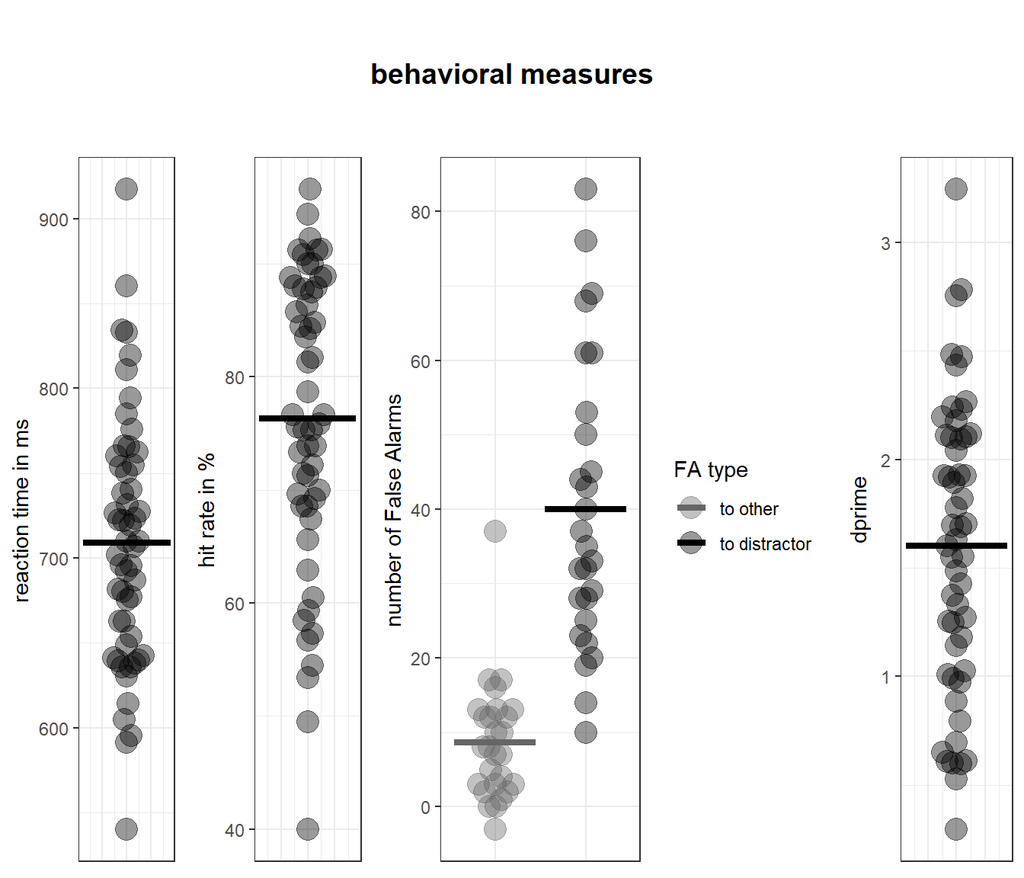

```r
dat2plot1 <- DATA_Trials %>%
  group_by(participant, eventtype2)%>%
  dplyr::summarise(
    RT_Mean=mean(RT,na.rm=TRUE),
    RT_STD=sd(RT,na.rm=TRUE),
    Hitrate=(sum(response=='hit')/n())*100,
    Hitrate_adj1 = ifelse((sum(response=='hit')/n())>0,
                         min(c(sum(response=='hit')/n(), 1-(.5/n()))),
                         .5/n()), # according to Stanislaw H, Todorov N, Behav Res Meth (1999) 31, 137-149, "1/2N rule" or
    Hitrate_adj2 = (sum(response=='hit')+0.5)/(n()+1))%>% # loglinear approach (Hautus, 1995)
    ungroup()
dat2plot1a = DataIn1%>%
  filter(eventtype=="distractor") %>%
  group_by(participant, eventtype2)%>%
  dplyr::summarise(
    FArate=(sum(response=='FA_proper')/n())*100,
    FArate_adj1 = ifelse((sum(response=='FA_proper')/n())>0,
                         min(c(sum(response=='FA_proper')/n(), 1-(.5/n()))),
                         .5/n()), # according to Stanislaw H, Todorov N, Behav Res Meth (1999) 31, 137-149, "1/2N rule" or
    FArate_adj2 = (sum(response=='FA_proper')+0.5)/(n()+1)) %>% # loglinear approach (Hautus, 1995))
  ungroup()
dat2plot <- merge(dat2plot1,dat2plot1a,by = "participant") %>% # adjust for HR and FR of 0 or 1
  mutate(
    d_prime = qnorm(Hitrate_adj1)-qnorm(FArate_adj1),
    c = -0.5*(qnorm(Hitrate_adj1)+qnorm(FArate_adj1))
  ) %>%
  dplyr::rename(eventtype2=eventtype2.x)




dat2plot2 <- DataIn2 %>%
  mutate(`FA_all`= FA + `FA_proper`)%>%
  # dplyr::select(-FA)%>%
  dplyr::select(-FA_all)%>%
  pivot_longer(c(-subject ),names_to = "FA_type", values_to = "number")%>%
  filter(FA_type=='FA_proper' | FA_type=='FA')

theme_set(theme_bw())
plot1 <- ggplot(dat2plot, aes(x = 1, y = RT_Mean)) +
  # geom_hline(yintercept=0, show.legend = FALSE) +
  geom_beeswarm(cex=4.5, size = 5,alpha=0.4)+
  stat_summary(fun.y=mean, aes(ymin=..y.., ymax=..y..), geom='errorbar', width=0.9, size=1.5) +
  # scale_fill_manual("attended color", values=c("darkcyan", "darkgreen", "darkorange")) +
  # scale_color_manual("attended color", values=c("darkcyan", "darkgreen", "darkorange")) +
  ylab(expression(paste("reaction time in ms")))+
  theme(axis.title.x=element_blank(),
        axis.text.x=element_blank(),
        axis.ticks.x=element_blank())

plot2 <- ggplot(dat2plot, aes(x = 1, y = Hitrate)) +
  # geom_hline(yintercept=0, show.legend = FALSE) +
  geom_beeswarm(cex=4.5, size = 5,alpha=0.4)+
  stat_summary(fun.y=mean, aes(ymin=..y.., ymax=..y..), geom='errorbar', width=0.9, size=1.5) +
  # scale_fill_manual("attended color", values=c("darkcyan", "darkgreen", "darkorange")) +
  # scale_color_manual("attended color", values=c("darkcyan", "darkgreen", "darkorange"))
  ylab(expression(paste("hit rate in %")))+
  theme(axis.title.x=element_blank(),
        axis.text.x=element_blank(),
        axis.ticks.x=element_blank())

plot3 <- ggplot(dat2plot2, aes(x = FA_type, y = number, color = FA_type)) +
  # geom_hline(yintercept=0, show.legend = FALSE) +
  geom_beeswarm(cex=3.5, size = 5,alpha=0.4)+
  stat_summary(fun.y=mean, aes(ymin=..y.., ymax=..y..), geom='errorbar', width=0.9, size=1.5) +
  scale_fill_manual("FA type", values=c("grey40", "black"),labels = c("to other","to distractor")) +
  scale_color_manual("FA type", values=c("grey40", "black"),labels = c("to other","to distractor")) +
  ylab(expression(paste("number of False Alarms")))+
  theme(axis.title.x=element_blank(),
        axis.text.x=element_blank(),
        axis.ticks.x=element_blank())

plot4 <- ggplot(dat2plot, aes(x = 1, y = d_prime)) +
  # geom_hline(yintercept=0, show.legend = FALSE) +
  geom_beeswarm(cex=4.5, size = 5,alpha=0.4)+
  stat_summary(fun.y=mean, aes(ymin=..y.., ymax=..y..), geom='errorbar', width=0.9, size=1.5) +
  # scale_fill_manual("attended color", values=c("darkcyan", "darkgreen", "darkorange")) +
  # scale_color_manual("attended color", values=c("darkcyan", "darkgreen", "darkorange"))
  ylab(expression(paste("dprime")))+
  theme(axis.title.x=element_blank(),
        axis.text.x=element_blank(),
        axis.ticks.x=element_blank())


# cowplot::plot_grid(plot1, plot2, plot3, ncol = 3,labels = "AUTO")
plotttitle <- ggdraw() + draw_label("behavioral measures", fontface='bold')
plotplots <- ggarrange(plot1, plot2, plot3, plot4, ncol = 4, align = "h", widths=c(2,2,5,2))
ggarrange(plotttitle, plotplots, nrow = 2, heights=c(0.2, 1))
```

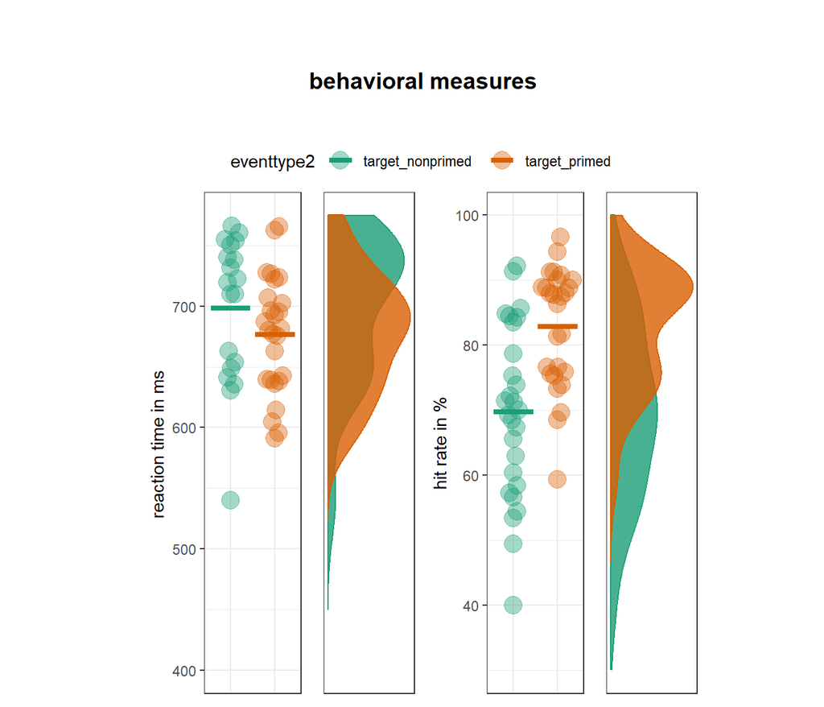

```r
## for publication
theme_set(theme_bw())
plot1 <- ggplot(dat2plot, aes(x = eventtype2, y = RT_Mean, color =eventtype2,)) +
  # geom_hline(yintercept=0, show.legend = FALSE) +
  geom_beeswarm(cex=4.5, size = 5,alpha=0.4)+
  stat_summary(fun.y=mean, aes(ymin=..y.., ymax=..y..), geom='errorbar', width=0.9, size=1.5) +
  scale_fill_brewer(palette = "Dark2")+
  scale_color_brewer(palette = "Dark2")+
  # scale_fill_manual("attended color", values=c("darkcyan", "darkgreen", "darkorange")) +
  # scale_color_manual("attended color", values=c("darkcyan", "darkgreen", "darkorange")) +
  ylab(expression(paste("reaction time in ms")))+
  theme(axis.title.x=element_blank(),
        axis.text.x=element_blank(),
        axis.ticks.x=element_blank())+
  scale_y_continuous(limits=c(400, 775))

plot1b <- ggplot(dat2plot, aes(x = 1, y = RT_Mean, color =eventtype2, fill = eventtype2)) +
  geom_flat_violin(position = position_nudge(x = .1, y = 0), adjust = 1.0, trim = FALSE, alpha = 0.8)+
  # scale_fill_manual(values=c("grey40"))+
  scale_fill_brewer(palette = "Dark2")+
  # scale_color_manual(values=c("grey40"))+
  scale_color_brewer(palette = "Dark2")+
  theme(axis.title.y=element_blank(),
         axis.text.y=element_blank(),
         axis.ticks.y=element_blank())+
  theme(axis.title.x=element_blank(),
         axis.text.x=element_blank(),
         axis.ticks.x=element_blank())+
  theme(panel.grid.major = element_blank(), panel.grid.minor = element_blank())+
  scale_y_continuous(limits=c(400, 775))

plot2 <- ggplot(dat2plot, aes(x = eventtype2, y = Hitrate, color =eventtype2)) +
  # geom_hline(yintercept=0, show.legend = FALSE) +
  geom_beeswarm(cex=4.5, size = 5,alpha=0.4)+
  stat_summary(fun.y=mean, aes(ymin=..y.., ymax=..y..), geom='errorbar', width=0.9, size=1.5) +
  scale_fill_brewer(palette = "Dark2")+
  scale_color_brewer(palette = "Dark2")+
    # scale_fill_manual("attended color", values=c("darkcyan", "darkgreen", "darkorange")) +
  # scale_color_manual("attended color", values=c("darkcyan", "darkgreen", "darkorange"))
  ylab(expression(paste("hit rate in %")))+
  theme(axis.title.x=element_blank(),
        axis.text.x=element_blank(),
        axis.ticks.x=element_blank())+
  scale_y_continuous(limits=c(30, 100))

plot2b <- ggplot(dat2plot, aes(x = 1, y = Hitrate,  color =eventtype2, fill = eventtype2)) +
  geom_flat_violin(position = position_nudge(x = .1, y = 0), adjust = 1.0, trim = FALSE, alpha = 0.8)+
  # scale_fill_manual(values=c("grey40"))+
  scale_fill_brewer(palette = "Dark2")+
  # scale_color_manual(values=c("grey40"))+
  scale_color_brewer(palette = "Dark2")+
  theme(axis.title.y=element_blank(),
         axis.text.y=element_blank(),
         axis.ticks.y=element_blank())+
  theme(axis.title.x=element_blank(),
         axis.text.x=element_blank(),
         axis.ticks.x=element_blank())+
  theme(panel.grid.major = element_blank(), panel.grid.minor = element_blank())+
  scale_y_continuous(limits=c(30, 100))



# cowplot::plot_grid(plot1, plot2, plot3, ncol = 3,labels = "AUTO")
plotttitle <- ggdraw() + draw_label("behavioral measures", fontface='bold')
plotplots <- ggarrange(plot1, plot1b,plot2, plot2b, ncol = 4,common.legend = TRUE,align = "h", widths=c(3,2,3,2))

savefig <- multi_panel_figure(columns = 1, rows = 1, panel_label_type = "none", width = 5, height = 6, unit = "in")
saveplot <- ggarrange(plotttitle, plotplots, nrow = 2, heights=c(0.2, 1))

savefig %<>%
  fill_panel(saveplot, column = 1, row = 1)
savefig
```

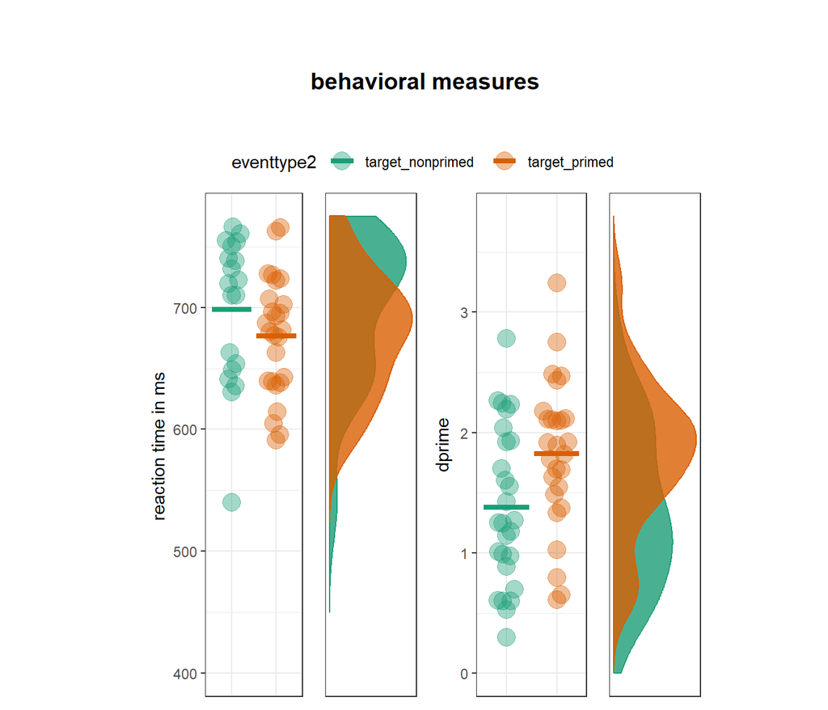

```r
# save_multi_panel_figure(savefig, "hits_reactiontimes.eps")


## for publication
theme_set(theme_bw())
plot1 <- ggplot(dat2plot, aes(x = eventtype2, y = RT_Mean, color =eventtype2)) +
  # geom_hline(yintercept=0, show.legend = FALSE) +
  geom_beeswarm(cex=4.5, size = 5,alpha=0.4)+
  stat_summary(fun.y=mean, aes(ymin=..y.., ymax=..y..), geom='errorbar', width=0.9, size=1.5) +
  scale_fill_brewer(palette = "Dark2")+
  scale_color_brewer(palette = "Dark2")+
  # scale_fill_manual("attended color", values=c("darkcyan", "darkgreen", "darkorange")) +
  # scale_color_manual("attended color", values=c("darkcyan", "darkgreen", "darkorange")) +
  ylab(expression(paste("reaction time in ms")))+
  theme(axis.title.x=element_blank(),
        axis.text.x=element_blank(),
        axis.ticks.x=element_blank())+
  scale_y_continuous(limits=c(400, 775))

plot1b <- ggplot(dat2plot, aes(x = 1, y = RT_Mean, color =eventtype2, fill = eventtype2)) +
  geom_flat_violin(position = position_nudge(x = .1, y = 0), adjust = 1.0, trim = FALSE, alpha = 0.8)+
  # scale_fill_manual(values=c("grey40"))+
  scale_fill_brewer(palette = "Dark2")+
  # scale_color_manual(values=c("grey40"))+
  scale_color_brewer(palette = "Dark2")+
  theme(axis.title.y=element_blank(),
         axis.text.y=element_blank(),
         axis.ticks.y=element_blank())+
  theme(axis.title.x=element_blank(),
         axis.text.x=element_blank(),
         axis.ticks.x=element_blank())+
  theme(panel.grid.major = element_blank(), panel.grid.minor = element_blank())+
  scale_y_continuous(limits=c(400, 775))

plot2 <- ggplot(dat2plot, aes(x = eventtype2, y = d_prime, color =eventtype2)) +
  # geom_hline(yintercept=0, show.legend = FALSE) +
  geom_beeswarm(cex=4.5, size = 5,alpha=0.4)+
  stat_summary(fun.y=mean, aes(ymin=..y.., ymax=..y..), geom='errorbar', width=0.9, size=1.5) +
  scale_fill_brewer(palette = "Dark2")+
  scale_color_brewer(palette = "Dark2")+
  # scale_fill_manual("attended color", values=c("darkcyan", "darkgreen", "darkorange")) +
  # scale_color_manual("attended color", values=c("darkcyan", "darkgreen", "darkorange"))
  ylab(expression(paste("dprime")))+
  theme(axis.title.x=element_blank(),
        axis.text.x=element_blank(),
        axis.ticks.x=element_blank())+
  scale_y_continuous(limits=c(0.0, 3.8))

plot2b <- ggplot(dat2plot, aes(x = 1, y = d_prime, color =eventtype2, fill = eventtype2)) +
  geom_flat_violin(position = position_nudge(x = .1, y = 0), adjust = 1.0, trim = FALSE, alpha = 0.8)+
  # scale_fill_manual(values=c("grey40"))+
  scale_fill_brewer(palette = "Dark2")+
  # scale_color_manual(values=c("grey40"))+
  scale_color_brewer(palette = "Dark2")+
  theme(axis.title.y=element_blank(),
         axis.text.y=element_blank(),
         axis.ticks.y=element_blank())+
  theme(axis.title.x=element_blank(),
         axis.text.x=element_blank(),
         axis.ticks.x=element_blank())+
  theme(panel.grid.major = element_blank(), panel.grid.minor = element_blank())+
  scale_y_continuous(limits=c(0.0, 3.8))



# cowplot::plot_grid(plot1, plot2, plot3, ncol = 3,labels = "AUTO")
plotttitle <- ggdraw() + draw_label("behavioral measures", fontface='bold')
plotplots <- ggarrange(plot1, plot1b,plot2, plot2b, ncol = 4,common.legend = TRUE,align = "h", widths=c(3,2,3,2))

savefig <- multi_panel_figure(columns = 1, rows = 1, panel_label_type = "none", width = 5, height = 6, unit = "in")
saveplot <- ggarrange(plotttitle, plotplots, nrow = 2, heights=c(0.2, 1))

savefig %<>%
  fill_panel(saveplot, column = 1, row = 1)
savefig
```

```r
# save_multi_panel_figure(savefig, "dprime_reactiontimes.eps")
```

## Display behavioral data numerically

```r
dat2plot1 <- DATA_Trials %>%
  group_by(eventtype2, participant )%>%
  dplyr::summarise(
    RT_Mean=mean(RT,na.rm=TRUE),
    RT_STD=sd(RT,na.rm=TRUE),
    Hitrate=(sum(response=='hit')/n())*100,
    Hitrate_adj1 = ifelse((sum(response=='hit')/n())>0,
                         min(c(sum(response=='hit')/n(), 1-(.5/n()))),
                         .5/n()), # according to Stanislaw H, Todorov N, Behav Res Meth (1999) 31, 137-149, "1/2N rule" or
    Hitrate_adj2 = (sum(response=='hit')+0.5)/(n()+1)) # loglinear approach (Hautus, 1995)
dat2plot1a = DataIn1%>%
  filter(eventtype=="distractor") %>%
  group_by(eventtype2, participant)%>%
  dplyr::summarise(
    FArate=(sum(response=='FA_proper')/n())*100,
    FArate_adj1 = ifelse((sum(response=='FA_proper')/n())>0,
                         min(c(sum(response=='FA_proper')/n(), 1-(.5/n()))),
                         .5/n()), # according to Stanislaw H, Todorov N, Behav Res Meth (1999) 31, 137-149, "1/2N rule" or
    FArate_adj2 = (sum(response=='FA_proper')+0.5)/(n()+1)) # loglinear approach (Hautus, 1995))
dat2plot <- merge(dat2plot1,dat2plot1a,by = "participant") %>% # adjust for HR and FR of 0 or 1
  mutate(
    d_prime = qnorm(Hitrate_adj1)-qnorm(FArate_adj1),
    c = -0.5*(qnorm(Hitrate_adj1)+qnorm(FArate_adj1))
  ) %>%
  dplyr::rename(eventtype2=eventtype2.x)

dat2plot  %>%
  group_by(eventtype2)%>%
  dplyr::summarise(N = n(), mean_RT = mean(RT_Mean), std_RT = sd(RT_Mean), mean_Hitrate = mean(Hitrate), std_Hitrate = sd(Hitrate),
            mean_FArate = mean(FArate), std_FArate = sd(FArate), mean_dprime = mean(d_prime), std_dprime = sd(d_prime)) %>%
  kable(escape = F, digits = c(3,3,3,3,3,3,3,3,3,3), caption = c("descriptives of behavioral measures")) %>%
  kable_styling("striped", full_width = T, bootstrap_options = c("striped", "hover", "condensed", "responsive",font_size = 8))
```

descriptives of behavioral measures

| eventtype2 | N | mean_RT | std_RT | mean_Hitrate | std_Hitrate | mean_FArate | std_FArate | mean_dprime | std_dprime |
| --- | --- | --- | --- | --- | --- | --- | --- | --- | --- |
| target_nonprimed | 27 | 737.28 | 82.383 | 69.733 | 13.324 | 22.222 | 10.811 | 1.377 | 0.654 |
| target_primed | 27 | 680.75 | 52.184 | 82.814 | 9.171 | 22.222 | 10.811 | 1.825 | 0.617 |

## Statistical analysis

### linear mixed models

#### test RT, Hitrate and dprime between primed and non primed targets

**RT** ~ **priming**

```r
dat2plot2 <- DataIn2 %>%
  mutate(`FA_all`= FA + `FA_proper`)%>%
  # dplyr::select(-FA)%>%
  dplyr::select(-FA_all)%>%
  pivot_longer(c(-subject ),names_to = "FA_type", values_to = "number")%>%
  filter(FA_type=='FA_proper' | FA_type=='FA')


dat2plot1 <- DATA_Trials %>%
  group_by(participant,eventtype2)%>%
  dplyr::summarise(RT_Mean=mean(RT,na.rm=TRUE),RT_STD=sd(RT,na.rm=TRUE),Hitrate=(sum(response=='hit')/n())*100)
dat2plot2 <- DataIn2 %>%
  mutate(`FA_all`= FA + `FA_proper`)%>%
  # dplyr::select(-FA)%>%
  dplyr::select(-FA_all)%>%
  dplyr::rename(participant=subject)

dat2plot_all <- merge(dat2plot1,dat2plot2,by = "participant") %>% # adjust for HR and FR of 0 or 1
  mutate(
    d_prime = qnorm(Hitrate)-qnorm(FA_proper_rate),
    c = -0.5*(qnorm(Hitrate)+qnorm(FA_proper_rate))
  )



# # statisticical analysis ANOVA
# StatsOut <- dat2plot_all %>%
#   aov_ez(id="participant", dv = "RT_Mean", data = ., between = c("colorlum"), include_aov = afex_options("include_aov"))
#
# StatsOut%>%
#   .$anova %>%
#   mutate(factor = rownames(.))%>%
#   mutate(
#     `Pr(>F)` = cell_spec(ifelse(round(`Pr(>F)`,4)<.001,"< .001",round(`Pr(>F)`,4)),
#                         color = ifelse(is.nan(`Pr(>F)`),"blue", ifelse(`Pr(>F)` < .05, "green", "red")),
#                         bold = ifelse(is.nan(`Pr(>F)`),F, ifelse(`Pr(>F)` < .05, T,F)),
#                         align = "center")
#   ) %>%
#   dplyr::select(`num Df`, `den Df`, MSE, `F`, ges, `Pr(>F)`) %>%
#   kable(escape = F, digits = c(3,3,3,3,3,3,3,3,3), caption = c("ANOVA | dv = RT in ms")) %>%
#   kable_styling("striped", full_width = T, bootstrap_options = c("striped", "hover", "condensed", "responsive",font_size = 6))


# RT
dat2plot_all %>%
  nest() %>%
  mutate(
    # stats = map(data, ~ broom::tidy(t.test(RT_Mean ~ eventtype2, data = ., paired = TRUE))),
    stats = map(data, ~ rstatix::t_test(RT_Mean ~ eventtype2, data = ., paired = TRUE, detailed = TRUE)),
    t_test_bf = map(data, ~ extractBF(ttestBF(formula = RT_Mean ~ eventtype2, data = .,
                                              iterations = num.iter, rscale = sqrt(2)/2))),
    meanval = map(data, ~ .x %>%
                    group_by(eventtype2) %>%
                    summarise(
                      mean_RT_Mean = mean(RT_Mean, na.rm = TRUE),
                      std_RT_Mean = sd(RT_Mean, na.rm = TRUE)
                    ) %>%
                    pivot_wider(names_from = eventtype2,
                                values_from = c(mean_RT_Mean, std_RT_Mean),
                                names_sep = "_")
    ),
    Dz = map(data, ~ rstatix::cohens_d(RT_Mean ~ eventtype2, data = ., paired = TRUE))
  ) %>%
  # unnest(cols = c(stats, cohens_d, t_test_bf, meanval))%>%
  unnest(cols = c(Dz))%>%
  dplyr::select(stats,t_test_bf, meanval, effsize) %>%
  unnest(cols = c(stats, t_test_bf, meanval)) %>%
  mutate(BF10 = bf, BF01 = 1/bf,
         M_RT_noprim = mean_RT_Mean_target_nonprimed,
         SD_RT_noprim = std_RT_Mean_target_nonprimed,
         M_RT_prim = mean_RT_Mean_target_primed,
         SD_RT_prim = std_RT_Mean_target_primed,
         diff=estimate,
         Dz = effsize, t.value=statistic)%>%
  dplyr::select(M_RT_noprim, SD_RT_noprim, M_RT_prim, SD_RT_prim, diff, t.value, df, p, Dz, BF10, BF01)%>%
  # mutate(p = p.adjust(p, method="holm")) %>% # none, holm
  # mutate(p = p.adjust(p, method="none")) %>% # none, holm
  ungroup()%>%
  # mutate(
  #   p = cell_spec(p, color = ifelse(is.nan(p),"blue", ifelse(p < .05, "green", "red")))
  # ) %>%
  mutate(
    p = cell_spec(ifelse(round(p,4)<.001,"< .001",round(p,4)),
                  color = ifelse(is.nan(p),"blue", ifelse(p < .05, "green", "red")),
                  bold = ifelse(is.nan(p),F, ifelse(p < .05, T,F)),
                  align = "center")
  ) %>%
  kbl(escape = F, digits = 3,
        caption = c("RT | modulation by target type (primed vs nonprimed) | t-tests of difference")) %>%
  kable_styling("striped", full_width = T,bootstrap_options = c("striped", "hover", "condensed", "responsive",font_size = 8))
```

RT | modulation by target type (primed vs nonprimed) | t-tests of difference

| M_RT_noprim | SD_RT_noprim | M_RT_prim | SD_RT_prim | diff | t.value | df | p | Dz | BF10 | BF01 |
| --- | --- | --- | --- | --- | --- | --- | --- | --- | --- | --- |
| 737.28 | 82.383 | 680.75 | 52.184 | 56.531 | 4.476 | 26 | < .001 | 0.861 | 9.939 | 0.101 |

**Hitrate** ~ **priming**

```r
# Hitrate
dat2plot_all %>%
  nest() %>%
  mutate(
    # stats = map(data, ~ broom::tidy(t.test(Hitrate ~ eventtype2, data = ., paired = FALSE))),
    stats = map(data, ~ rstatix::t_test(Hitrate ~ eventtype2, data = ., paired = TRUE, detailed = TRUE)),
    t_test_bf = map(data, ~ extractBF(ttestBF(formula = Hitrate ~ eventtype2, data = ., iterations = num.iter, rscale = sqrt(2)/2))),
    meanval = map(data, ~ .x %>%
                    group_by(eventtype2) %>%
                    summarise(
                      mean_HR_Mean = mean(Hitrate, na.rm = TRUE),
                      std_HR_Mean = sd(Hitrate, na.rm = TRUE)
                    ) %>%
                    pivot_wider(names_from = eventtype2,
                                values_from = c(mean_HR_Mean, std_HR_Mean),
                                names_sep = "_")
    ),
    cohens_d = map(data, ~ rstatix::cohens_d(Hitrate ~ eventtype2, data = ., paired = FALSE))
  ) %>%
  # unnest(cols = c(stats, cohens_d, t_test_bf, meanval))%>%
  unnest(cols = c(cohens_d))%>%
  dplyr::select(stats,t_test_bf, meanval, effsize) %>%
  unnest(cols = c(stats, t_test_bf, meanval)) %>%
  mutate(BF10 = bf, BF01 = 1/bf,
         M_HR_noprim = mean_HR_Mean_target_nonprimed,
         SD_HR_noprim = std_HR_Mean_target_nonprimed,
         M_HR_prim = mean_HR_Mean_target_primed,
         SD_HR_prim = std_HR_Mean_target_primed,
         diff=estimate,
         Dz = effsize, t.value=statistic)%>%
  dplyr::select(M_HR_noprim, SD_HR_noprim, M_HR_prim, SD_HR_prim, diff, t.value, df, p, Dz, BF10, BF01)%>%
  # mutate(p = p.adjust(p, method="holm")) %>% # none, holm
  # mutate(p = p.adjust(p, method="none")) %>% # none, holm
  ungroup()%>%
  mutate(
    p = cell_spec(ifelse(round(p,4)<.001,"< .001",round(p,4)),
                        color = ifelse(is.nan(p),"blue", ifelse(p < .05, "green", "red")),
                        bold = ifelse(is.nan(p),F, ifelse(p < .05, T,F)),
                        align = "center")
  ) %>%
  kbl(escape = F, digits = 3,
        caption = c("Hitrate | modulation by target type (primed vs nonprimed) | t-tests of difference")) %>%
  kable_styling("striped", full_width = T,bootstrap_options = c("striped", "hover", "condensed", "responsive",font_size = 8))
```

Hitrate | modulation by target type (primed vs nonprimed) | t-tests of difference

| M_HR_noprim | SD_HR_noprim | M_HR_prim | SD_HR_prim | diff | t.value | df | p | Dz | BF10 | BF01 |
| --- | --- | --- | --- | --- | --- | --- | --- | --- | --- | --- |
| 69.733 | 13.324 | 82.814 | 9.171 | -13.081 | -6.362 | 26 | < .001 | -1.144 | 213.38 | 0.005 |

## Time-resolved Analysis

### Hitrates

#### Display of hit-rate distributions

What are the distributions of presentation times for detected primed and nonprimed events?

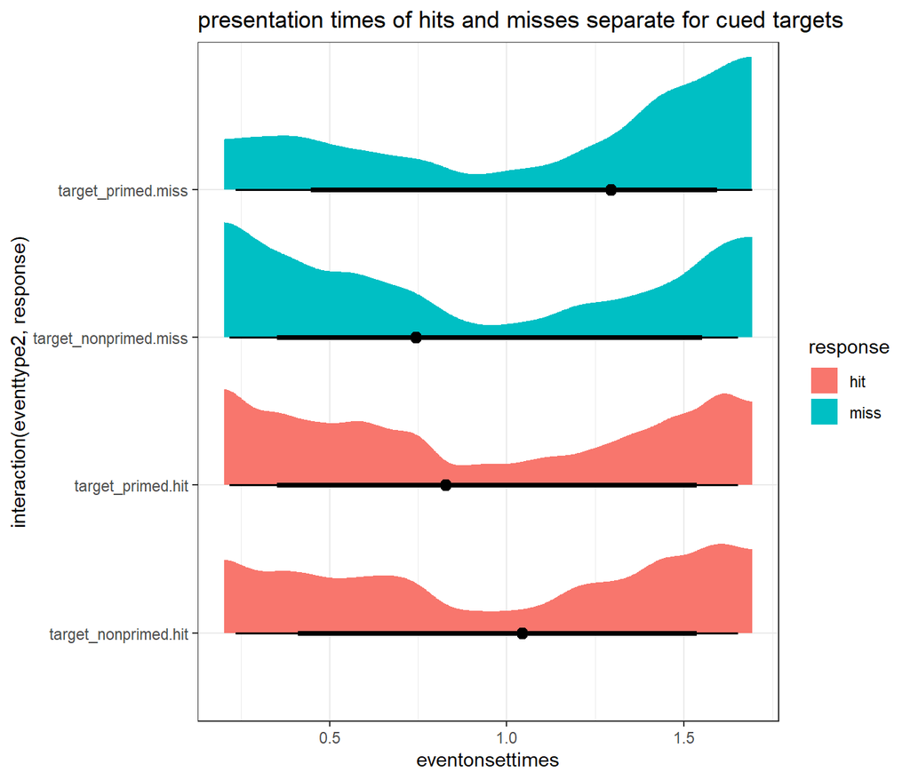

```r
# DATA_Trials %>%
#   filter(response=='hit') %>%
#   group_by(eventtype2, participant) %>%
#   summarise(
#     mean_presentation_time = mean(eventonsettimes, na.rm = TRUE),
#     std_presentation_time = sd(eventonsettimes, na.rm = TRUE)
#   ) %>%
#   ungroup() %>%
#   mutate(
#     eventtype2 = factor(eventtype2, levels = c("target_nonprimed", "target_primed"))
#   ) %>%
#   ggplot(aes(x = eventtype2, y = mean_presentation_time)) +
#   geom_bar(stat = "identity", position = position_dodge(), fill = "steelblue") +
#   geom_errorbar(aes(ymin = mean_presentation_time - std_presentation_time, ymax = mean_presentation_time + std_presentation_time), width = 0.2, position = position_dodge(0.9)) +
#   labs(x = "Event Type", y = "Mean Presentation Time (ms)") +
#   theme_minimal()


DATA_Trials %>%
  ggplot(aes(y = interaction(eventtype2,response), x = eventonsettimes, fill=response)) +
  stat_halfeye(position = position_dodgejust(width = .2)) +
  # stat_histinterval() +
  # stat_slab(height = 2, color = "black")+
  # stat_dots(color = "grey")+
  # stat_dots(quantiles = 90, color = "grey",fill="darkgrey")+
  # stat_dots(quantiles = 90, color = "grey")+
  ggtitle("presentation times of hits and misses separate for cued targets")
```

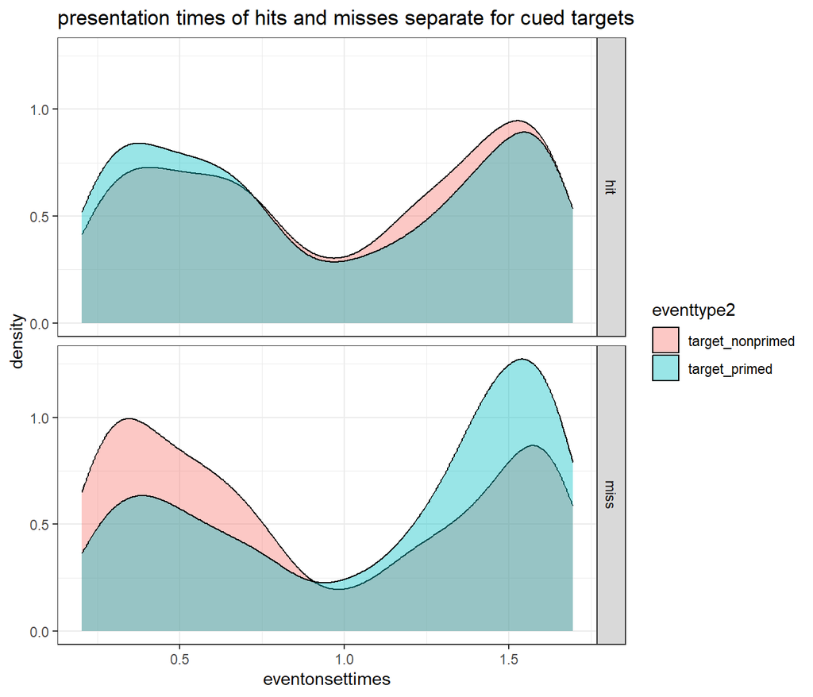

```r
DATA_Trials %>%
  ggplot(aes( x = eventonsettimes,  fill=eventtype2)) +
  geom_density(alpha=0.4,bw=0.1) +
  # stat_density(adjust = 0.5, alpha=0.4)+
  facet_grid(response~.)+
  # stat_histinterval() +
  # stat_slab(height = 2, color = "black")+
  # stat_dots(color = "grey")+
  # stat_dots(quantiles = 90, color = "grey",fill="darkgrey")+
  # stat_dots(quantiles = 90, color = "grey")+
  ggtitle("presentation times of hits and misses separate for cued targets")
```

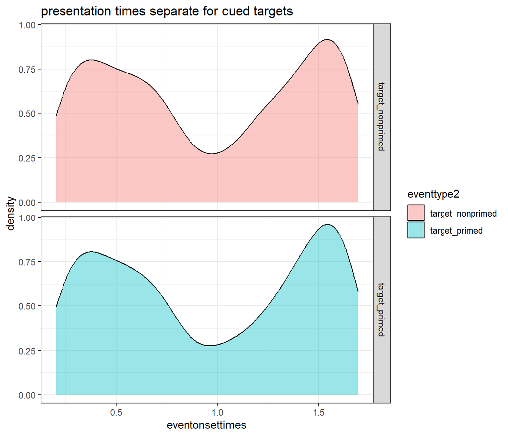

```r
DATA_Trials %>%
  ggplot(aes( x = eventonsettimes,  fill=eventtype2)) +
  geom_density(alpha=0.4,bw=0.1) +
  # stat_density(adjust = 0.5, alpha=0.4)+
  facet_grid(eventtype2~.)+
  # stat_histinterval() +
  # stat_slab(height = 2, color = "black")+
  # stat_dots(color = "grey")+
  # stat_dots(quantiles = 90, color = "grey",fill="darkgrey")+
  # stat_dots(quantiles = 90, color = "grey")+
  ggtitle("presentation times separate for cued targets")
```

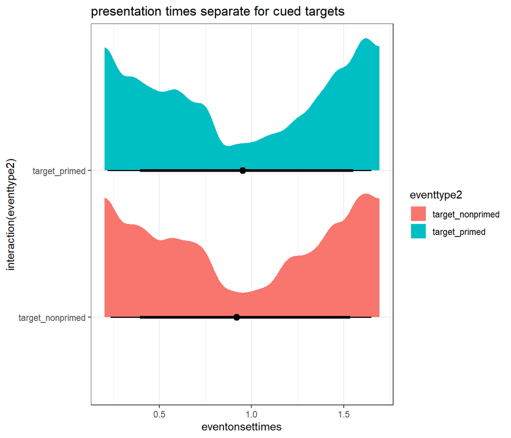

```r
DATA_Trials %>%
  ggplot(aes(y = interaction(eventtype2), x = eventonsettimes,  fill=eventtype2))+
  stat_halfeye(position = position_dodgejust(width = .2)) +
  # stat_histinterval() +
  # stat_slab(height = 2, color = "black")+
  # stat_dots(color = "grey")+
  # stat_dots(quantiles = 90, color = "grey",fill="darkgrey")+
  # stat_dots(quantiles = 90, color = "grey")+
  ggtitle("presentation times separate for cued targets")
```

```r
# DATA_Trials %>%
#   filter(response=='hit')%>%
#   ggplot(aes(x = eventonsettimes, y = RT, color = eventtype2)) +
#   stat_summary(fun = mean, geom = "point", alpha = 0.4) +  # mean RTs
#   geom_smooth(method = "loess", se = TRUE, span = 0.3) +    # kernel smoothed average
#   labs(
#     title = "Smoothed Average Reaction Times",
#     x = "Presentation Time (ms)",
#     y = "Reaction Time (ms)",
#     color = "Condition"
#   ) +
#   theme_minimal()
```

#### Display of smoothed Hit rates across time and experimental conditions

What are the time courses of detected primed and nonprimed events?

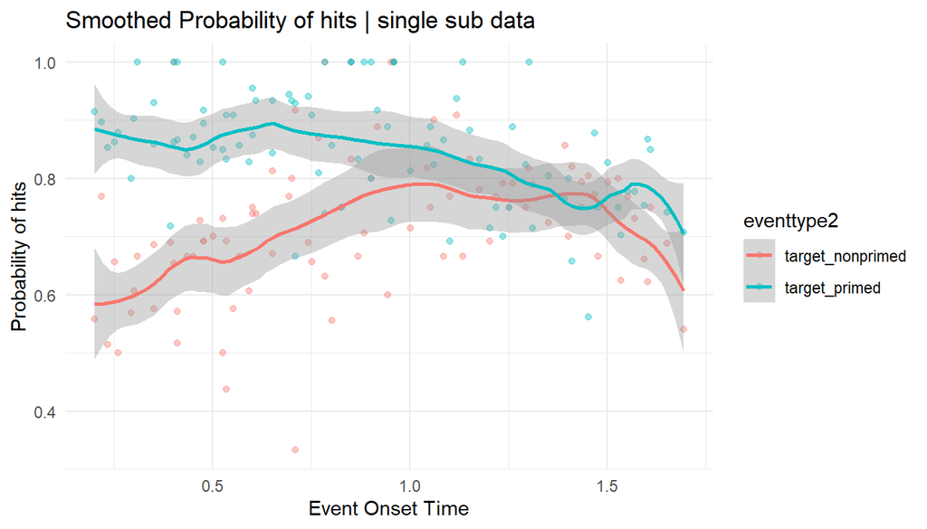

```r
data_bin <- DATA_Trials %>%
  mutate(hit = ifelse(response == "hit", 1, 0))

data_avg <- data_bin %>%
  group_by(eventtype2, eventonsettimes) %>%
  summarise(hit_rate = mean(hit), .groups = "drop")


ggplot(data_bin, aes(x = eventonsettimes, y = hit, color = eventtype2)) +
  stat_summary(fun = mean, geom = "point", alpha = 0.4) +  # mean RTs
  geom_smooth(method = "loess", span = 0.3, se = TRUE) +
  labs(x = "Event Onset Time", y = "Probability of hits",
       title = "Smoothed Probability of hits | single sub data") +
  theme_minimal()
```

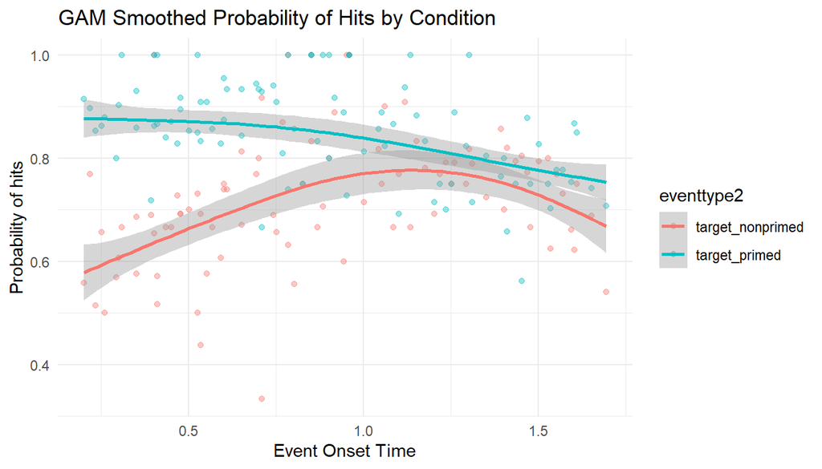

```r
# ggplot(data_avg, aes(x = eventonsettimes, y = hit_rate, color = eventtype2)) +
#   # geom_line(alpha = 0.4) +
#   stat_summary(fun = mean, geom = "point", alpha = 0.4) +  # mean RTs
#   geom_smooth(method = "loess", se = TRUE, span = 0.3) +
#   labs(x = "Event Onset Time", y = "Hit Rate",
#        title = "Smoothed Hit Rates Over Time by Condition | averaged across subjects hit rates") +
#   theme_minimal()


ggplot(data_bin, aes(x = eventonsettimes, y = hit, color = eventtype2)) +
  stat_summary(fun = mean, geom = "point", alpha = 0.4) +  # mean RTs
  geom_smooth(method = "gam", formula = y ~ s(x, bs = "cs"), se = TRUE) +
  labs(x = "Event Onset Time", y = "Probability of hits",
       title = "GAM Smoothed Probability of Hits by Condition") +
  theme_minimal()
```

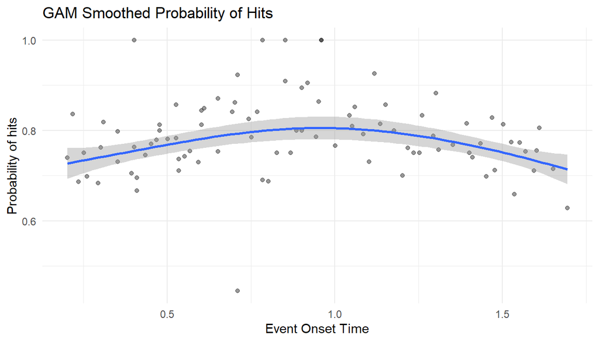

```r
ggplot(data_bin, aes(x = eventonsettimes, y = hit)) +
  stat_summary(fun = mean, geom = "point", alpha = 0.4) +  # mean RTs
  geom_smooth(method = "gam", formula = y ~ s(x, bs = "cs"), se = TRUE) +
  labs(x = "Event Onset Time", y = "Probability of hits",
       title = "GAM Smoothed Probability of Hits") +
  theme_minimal()
```

#### Statistical test for time-resolved analysis of probability of hits/hit rates

*Do probabilities of Hits for primed and non-primed events differ (differently) across time?*

full model: response ~ eventtype2 * eventonsettimes + (1 | participant) reduced model: response ~ eventtype2 + eventonsettimes + (1 | participant)

Test rationale: do these models differ significantly and does the interaction term thus allow for a better explanation of the data.

```r
# Full model with interaction
GLMHit_full <- DATA_Trials %>%
  mutate(response = as.factor(response)) %>%
  glmer(response ~ eventtype2 * eventonsettimes + (1 | participant),data=., family = binomial)

# Reduced model without the interaction
GLMHit_reduced <- DATA_Trials %>%
  mutate(response = as.factor(response)) %>%
  glmer(response ~ eventtype2 + eventonsettimes + (1 | participant),data=., family = binomial)

# Likelihood ratio test
anova( GLMHit_reduced, GLMHit_full, test = "Chisq") %>%
  as.data.frame() %>%
  kable(escape = F, digits=6,
        caption = paste0("Likelihood ratio test via anova | comparing full and reduced model:<br>",
                    deparse(formula(GLMHit_full))))%>%
  kable_styling("striped", full_width = T, bootstrap_options = c("striped", "hover", "condensed", "responsive",font_size = 8,latex_options = "hold_position"))
```

Likelihood ratio test via anova | comparing full and reduced model: response ~ eventtype2 * eventonsettimes + (1 | participant)

|  | npar | AIC | BIC | logLik | -2*log(L) | Chisq | Df | Pr(>Chisq) |
| --- | --- | --- | --- | --- | --- | --- | --- | --- |
| GLMHit_reduced | 4 | 5028.4 | 5054.4 | -2510.2 | 5020.4 | NA | NA | NA |
| GLMHit_full | 5 | 4975.1 | 5007.6 | -2482.6 | 4965.1 | 55.304 | 1 | 0 |

```r
# Display the summary of the full model + Wald test
GLMHit_full %>%
  tidy() %>%
  kable(escape = F, digits=3,
        caption = paste0("Likelihood ratio test via anova | comparing full and reduced model:<br>",
                    deparse(formula(GLMHit_full)))) %>%
  kable_styling("striped", full_width = T, bootstrap_options = c("striped", "hover", "condensed", "responsive",font_size = 8))
```

Likelihood ratio test via anova | comparing full and reduced model: response ~ eventtype2 * eventonsettimes + (1 | participant)

| effect | group | term | estimate | std.error | statistic | p.value |
| --- | --- | --- | --- | --- | --- | --- |
| fixed | NA | (Intercept) | -0.534 | 0.149 | -3.574 | 0 |
| fixed | NA | eventtype2target_primed | -1.834 | 0.164 | -11.217 | 0 |
| fixed | NA | eventonsettimes | -0.393 | 0.092 | -4.278 | 0 |
| fixed | NA | eventtype2target_primed:eventonsettimes | 1.069 | 0.145 | 7.372 | 0 |
| ran_pars | participant | sd__(Intercept) | 0.591 | NA | NA | NA |

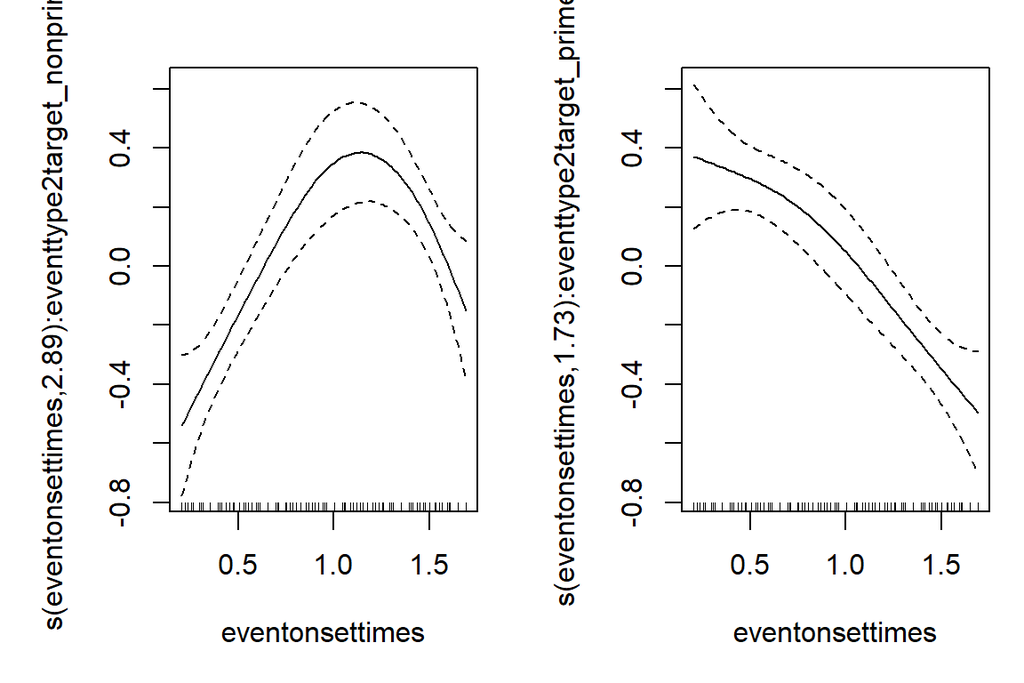

```r
# Model with smoothers by condition
model_gam_interaction <- DATA_Trials %>%
  mutate(hit = ifelse(response == "hit", 1, 0),
         eventtype2 = as.factor(eventtype2))%>%
  gam(hit ~ eventtype2 + s(eventonsettimes, by = eventtype2, bs = "cs") + participant,
                 data = ., family = binomial)
# coef(model_gam_interaction)



model_gam_null <- DATA_Trials %>%
  mutate(hit = ifelse(response == "hit", 1, 0),
         eventtype2 = as.factor(eventtype2))%>%
  gam(hit ~ eventtype2 + s(eventonsettimes, bs = "cs") + participant,
                 data = ., family = binomial)

plot(model_gam_interaction, pages = 1)
```

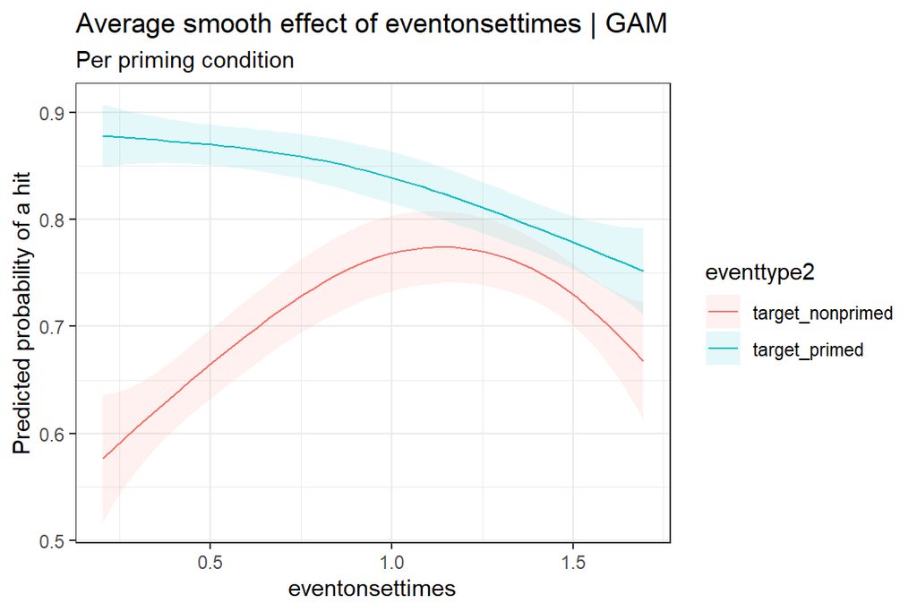

```r
# anova(model_gam_interaction)


plot_predictions(model_gam_interaction, condition = c('eventonsettimes', 'eventtype2'),
                 type = 'response') +
      labs(y = "Predicted probability of a hit",
           title = "Average smooth effect of eventonsettimes | GAM",
           subtitle = "Per priming condition")
```

```r
# Likelihood ratio test
anova( model_gam_null, model_gam_interaction, test = "Chisq") %>%
  tidy()%>%
  # as.data.frame() %>%
  # mutate(model = c('reduced model','full model')) %>%
  # dplyr::select(model, `Resid. Df`:`Pr(>Chi)`)%>%
  kbl(escape = F, digits=3,
      caption = paste0("Likelihood ratio test via anova | comparing full and reduced model | GAM:"))%>%
        # caption = paste0("Likelihood ratio test via anova | comparing full and reduced model | GAM:<br>",
        #             paste(deparse(formula(model_gam_interaction)), collapse = " ")))%>%
  kable_styling("striped", full_width = T, bootstrap_options = c("striped", "hover", "condensed", "responsive",font_size = 8,latex_options = "hold_position"))
```

Likelihood ratio test via anova | comparing full and reduced model | GAM:

| term | df.residual | residual.deviance | df | deviance | p.value |
| --- | --- | --- | --- | --- | --- |
| hit ~ eventtype2 + s(eventonsettimes, bs = “cs”) + participant | 4853.8 | 5184.1 | NA | NA | NA |
| hit ~ eventtype2 + s(eventonsettimes, by = eventtype2, bs = “cs”) + participant | 4851.2 | 5128.7 | 2.621 | 55.422 | 0 |

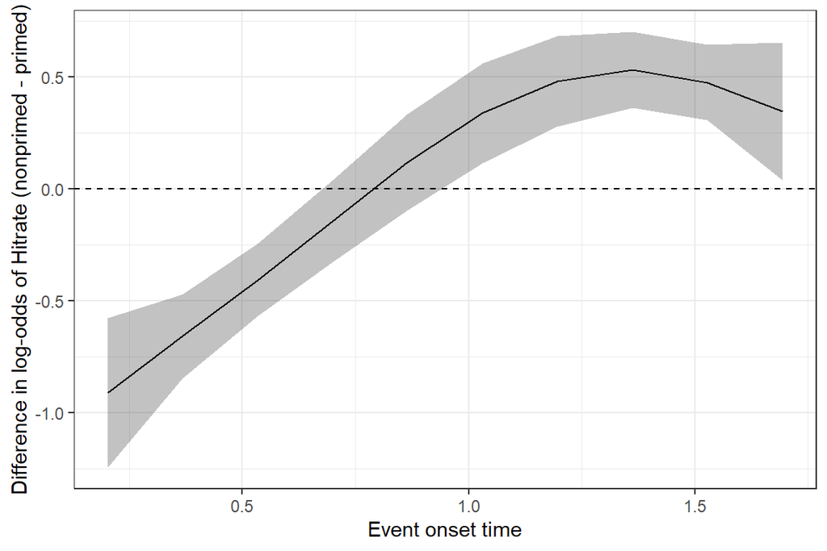

```r
# Plot difference between smooths (e.g., eventtype2 levels "A" and "B")
diff_df <- difference_smooths(model_gam_interaction,
                               smooth = "s(eventonsettimes)",
                               comparison = c("eventtype2A", "eventtype2B"),
                               n = 10)  # 200 points across the range

# diff_df <- diff_df %>%
#   mutate(
#     .diff = plogis(.diff),
#     .lower_c = plogis(.lower_ci),
#     .upper_ci = plogis(.upper_ci)
#   )

ggplot(diff_df, aes(x = eventonsettimes, y = .diff)) +
  geom_line() +
  geom_ribbon(aes(ymin = .lower_ci, ymax = .upper_ci), alpha = 0.3) +
  geom_hline(yintercept = 0, linetype = "dashed") +
  labs(x = "Event onset time", y = "Difference in log-odds of Hitrate (nonprimed - primed)")
```

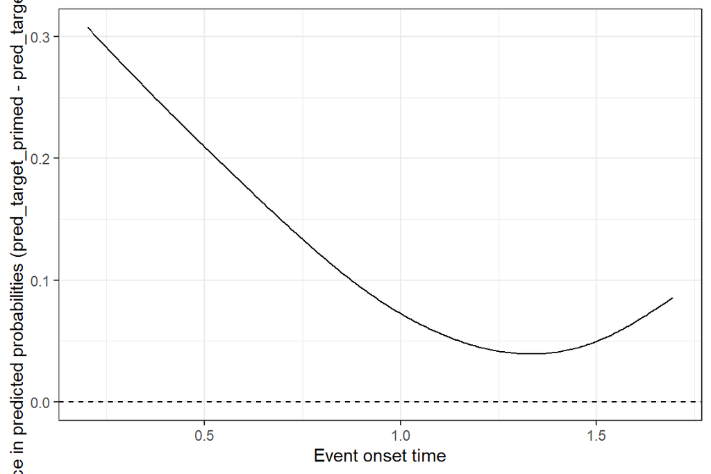

```r
# The y-axis shows the linear predictor — that is, the log-odds of the outcome ("hit") as predicted by the model.
#
# This is before applying the inverse link function (which would convert it to a probability).
#
# That means:
# Y-axis = logit(P(hit))
#
# Values:
#
# 0 → 50% chance of a hit
#
# Positive values → >50% chance
#
# Negative values → <50% chance



eventonset_grid <- seq(min(DATA_Trials$eventonsettimes),
                       max(DATA_Trials$eventonsettimes),
                       length.out = 200)

new_target_primed <- data.frame(eventonsettimes = eventonset_grid,
                    eventtype2 = "target_primed",  # match your factor levels exactly
                    participant = 1)

new_target_nonprimed <- data.frame(eventonsettimes = eventonset_grid,
                    eventtype2 = "target_nonprimed",
                    participant = 1)

pred_target_primed <- predict(model_gam_interaction, newdata = new_target_primed, type = "response")
pred_target_nonprimed <- predict(model_gam_interaction, newdata = new_target_nonprimed, type = "response")

prob_diff_df <- data.frame(
  eventonsettimes = eventonset_grid,
  prob_target_primed = pred_target_primed,
  prob_target_nonprimed = pred_target_nonprimed,
  prob_diff = pred_target_primed - pred_target_nonprimed
)

ggplot(prob_diff_df, aes(x = eventonsettimes, y = prob_diff)) +
  geom_line() +
  geom_hline(yintercept = 0, linetype = "dashed") +
  labs(y = "Difference in predicted probabilities (pred_target_primed - pred_target_nonprimed)",
       x = "Event onset time")
```

```r
coef(GLMHit_full)
```

```
## $participant
##    (Intercept) eventtype2target_primed eventonsettimes
## 1    -0.182329                 -1.8343         -0.3929
## 2     0.336371                 -1.8343         -0.3929
## 3    -1.071064                 -1.8343         -0.3929
## 4    -1.470301                 -1.8343         -0.3929
## 5    -1.757981                 -1.8343         -0.3929
## 6     0.423533                 -1.8343         -0.3929
## 7    -0.311188                 -1.8343         -0.3929
## 8    -0.023459                 -1.8343         -0.3929
## 9    -0.365949                 -1.8343         -0.3929
## 10   -0.186298                 -1.8343         -0.3929
## 11   -1.052587                 -1.8343         -0.3929
## 12   -0.971387                 -1.8343         -0.3929
## 13   -0.850055                 -1.8343         -0.3929
```

[output cut: 45 more lines]

##### follow up: directly test time windows | Hitrates

*Do probabilities of Hits for primed and non-primed events differ (differently) across time?*

full model: response ~ eventtype2 * eventonsettimes + (1 | participant)

Test rationale: do these models differ significantly and does the interaction term thus allow for a better explanation of the data.

Extract predicted probability of hits for early and late window and contrast them

```r
# Full model with interaction
model_gam_interaction <- DATA_Trials %>%
  mutate(hit = ifelse(response == "hit", 1, 0),
         eventtype2 = as.factor(eventtype2))%>%
  gam(hit ~ eventtype2 + s(eventonsettimes, by = eventtype2, bs = "cs") + participant,
                 data = ., family = binomial)


# based on gam interactions
# Define the time windows
early_window <- c(0, 0.5) + min(DATA_Trials$eventonsettimes)
late_window <- c(-0.5, 0) + max(DATA_Trials$eventonsettimes)

# Calculate the average predicted hit probability for each time window
# and for each event type (attended vs. unattended).
# We'll use the 'at' argument to specify the time points of interest.
emm_predictions <- emmeans(
  model_gam_interaction,
  ~ eventtype2 | eventonsettimes,
  at = list(eventonsettimes = c(mean(early_window), mean(late_window)))
)

summary(emm_predictions, type = "response") %>%
  as.data.frame()%>%
  mutate(eventonsettimes=c("early","early","late","late"))%>%
  kbl(escape = F, digits=4,
      caption = paste0("Marginal Mean predicted Probabilities in early and late time window"))%>%
        # caption = paste0("Likelihood ratio test via anova | comparing full and reduced model | GAM:<br>",
        #             paste(deparse(formula(model_gam_interaction)), collapse = " ")))%>%
  kable_styling("striped", full_width = T, bootstrap_options = c("striped", "hover", "condensed", "responsive",font_size = 8,latex_options = "hold_position"))
```

Marginal Mean predicted Probabilities in early and late time window

| eventtype2 | eventonsettimes | prob | SE | df | lower.CL | upper.CL |
| --- | --- | --- | --- | --- | --- | --- |
| target_nonprimed | early | 0.6515 | 0.0164 | 4852.4 | 0.6188 | 0.6829 |
| target_primed | early | 0.8714 | 0.0098 | 4852.4 | 0.8509 | 0.8895 |
| target_nonprimed | late | 0.7431 | 0.0145 | 4852.4 | 0.7137 | 0.7704 |
| target_primed | late | 0.7861 | 0.0120 | 4852.4 | 0.7617 | 0.8087 |

```r
# Now, set up the contrast to compare early vs. late for each condition.
# This will perform a pairwise comparison for each event type.
# do everything on the response scale, i.e. probability scale
emm_response_scale <- regrid(emm_predictions)

# Now perform the contrasts on the regridded object
contrast_tdiffs <- contrast(
  emm_response_scale,
  method = "pairwise",
  by = "eventtype2",
  adjust= "holm"
)


# View the results on the probability scale
summary(contrast_tdiffs) %>%
  as.data.frame()%>%
  mutate(contrast = c("early vs late"))%>%
  mutate(
    p.value = cell_spec(ifelse(round(p.value,4)<.001,"< .001",round(p.value,4)),
                        color = ifelse(is.nan(p.value),"blue", ifelse(p.value < .05, "green", "red")),
                        bold = ifelse(is.nan(p.value),F, ifelse(p.value < .05, T,F)),
                        align = "center")
  ) %>%
  mutate(`CohensD1` =
           summary(eff_size(contrast_tdiffs,
                            sigma = sqrt(mean(sigma(model_gam_interaction, type = "response")^2)), # RMS of sigma()
                            edf = df.residual(model_gam_interaction), method = "identity"))$effect.size
  )%>%
  mutate(`CohensD2` =
           summary(eff_size(contrast_tdiffs,
                            sigma = sqrt(mean(sigma(model_gam_interaction, type = "response")^2)), # RMS of sigma()
                            edf = sum(model_gam_interaction$edf), method = "identity"))$effect.size
  )%>%
  kbl(escape = F, digits=4,
      caption = paste0("Contrast of marginal means of hit rates between early and late time window | Holm corrected"))%>%
        # caption = paste0("Likelihood ratio test via anova | comparing full and reduced model | GAM:<br>",
        #             paste(deparse(formula(model_gam_interaction)), collapse = " ")))%>%
  kable_styling("striped", full_width = T, bootstrap_options = c("striped", "hover", "condensed", "responsive",font_size = 8,latex_options = "hold_position"))
```

Contrast of marginal means of hit rates between early and late time window | Holm corrected

| contrast | eventtype2 | estimate | SE | df | t.ratio | p.value | CohensD1 | CohensD2 |
| --- | --- | --- | --- | --- | --- | --- | --- | --- |
| early vs late | target_nonprimed | -0.0916 | 0.0221 | 4852.4 | -4.1472 | < .001 | -0.0916 | -0.0916 |
| early vs late | target_primed | 0.0853 | 0.0154 | 4852.4 | 5.5426 | < .001 | 0.0853 | 0.0853 |

```r
# Now perform the contrasts on the regridded object
contrast_condiffs <- contrast(
  emm_response_scale,
  method = "pairwise",
  by = "eventonsettimes",
  adjust= "holm"
)


# View the results on the probability scale
summary(contrast_condiffs) %>%
  as.data.frame()%>%
  mutate(eventonsettimes = c("early","late"))%>%
  mutate(
    p.value = cell_spec(ifelse(round(p.value,4)<.001,"< .001",round(p.value,4)),
                        color = ifelse(is.nan(p.value),"blue", ifelse(p.value < .05, "green", "red")),
                        bold = ifelse(is.nan(p.value),F, ifelse(p.value < .05, T,F)),
                        align = "center")
  ) %>%
  mutate(`CohensD1` =
           summary(eff_size(contrast_condiffs,
                            sigma = sqrt(mean(sigma(model_gam_interaction, type = "response")^2)), # RMS of sigma()
                            edf = df.residual(model_gam_interaction), method = "identity"))$effect.size
  )%>%
  mutate(`CohensD2` =
           summary(eff_size(contrast_condiffs,
                            sigma = sqrt(mean(sigma(model_gam_interaction, type = "response")^2)), # RMS of sigma()
                            edf = sum(model_gam_interaction$edf), method = "identity"))$effect.size
  )%>%
  kbl(escape = F, digits=4,
      caption = paste0("Contrast of marginal means of hit rates between conditions | Holm corrected"))%>%
        # caption = paste0("Likelihood ratio test via anova | comparing full and reduced model | GAM:<br>",
        #             paste(deparse(formula(model_gam_interaction)), collapse = " ")))%>%
  kable_styling("striped", full_width = T, bootstrap_options = c("striped", "hover", "condensed", "responsive",font_size = 8,latex_options = "hold_position"))
```

Contrast of marginal means of hit rates between conditions | Holm corrected

| contrast | eventonsettimes | estimate | SE | df | t.ratio | p.value | CohensD1 | CohensD2 |
| --- | --- | --- | --- | --- | --- | --- | --- | --- |
| target_nonprimed - target_primed | early | -0.2199 | 0.0191 | 4852.4 | -11.515 | < .001 | -0.2199 | -0.2199 |
| target_nonprimed - target_primed | late | -0.0430 | 0.0188 | 4852.4 | -2.289 | 0.0221 | -0.0430 | -0.0430 |

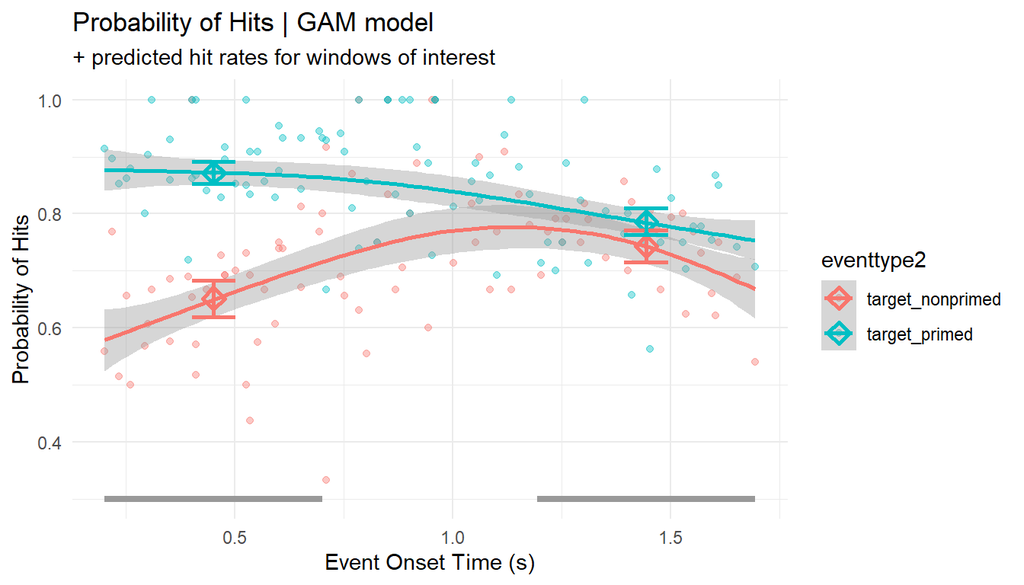

```r
emm_predictions_plot <- emmeans(
  model_gam_interaction,
  ~ eventtype2 | eventonsettimes,
  at = list(eventonsettimes = c(mean(early_window), mean(late_window)))
) %>%
  regrid()%>%
  as.data.frame()


# Base plot with original data and GAM smoothed line
DATA_Trials %>%
  mutate(hit = ifelse(response == "hit", 1, 0),
         eventtype2 = as.factor(eventtype2))%>%
  ggplot(., aes(x = eventonsettimes, y = as.numeric(hit), color = eventtype2)) +
  stat_summary(fun = mean, geom = "point", alpha = 0.4) +
  # stat_summary(fun.data = mean_se, geom = "errorbar", width = 0.02, alpha = 0.4) + # Optional: add standard error bars
  geom_smooth(method = "gam", formula = y ~ s(x, bs = "cs"), se = TRUE, aes(group = eventtype2)) +
  labs(x = "Event Onset Time (s)", y = "Probability of Hits",
       title = "Probability of Hits | GAM model", subtitle = "+ predicted hit rates for windows of interest") +
  geom_point(data = emm_predictions_plot, aes(y = prob, group = eventtype2), size = 3, shape = 23, stroke = 1.5) +
  geom_errorbar(data = emm_predictions_plot, aes(y = prob,ymin = lower.CL, ymax = upper.CL), width = 0.1, size = 1) +
  # Add vertical lines for the early time window
  annotate("segment", x = early_window[1], xend = early_window[2], y = 0.3, yend = 0.3, color = "grey60", size = 1.5) +
  annotate("segment", x = late_window[1], xend = late_window[2], y = 0.3, yend = 0.3, color = "grey60", size = 1.5) +
  theme_minimal()
```

### Reaction Times

#### Display of smoothed reaction times across time

What are the distributions of reaction times for primed and nonprimed events across the trial?

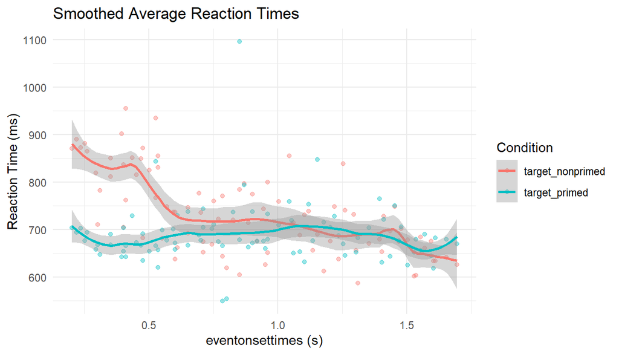

```r
DATA_Trials %>%
  filter(response=='hit')%>%
  ggplot(aes(x = eventonsettimes, y = RT, color = eventtype2)) +
  stat_summary(fun = mean, geom = "point", alpha = 0.4) +  # mean RTs
  geom_smooth(method = "loess", se = TRUE, span = 0.3) +    # kernel smoothed average
  labs(
    title = "Smoothed Average Reaction Times",
    x = "eventonsettimes (s)",
    y = "Reaction Time (ms)",
    color = "Condition"
  ) +
  theme_minimal()
```

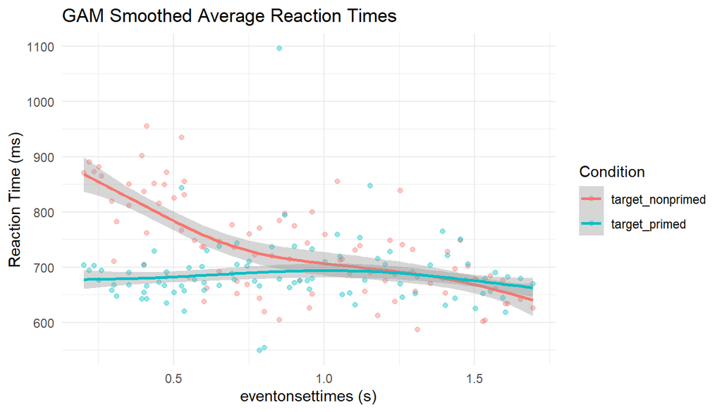

```r
DATA_Trials %>%
  filter(response=='hit')%>%
  ggplot(aes(x = eventonsettimes, y = RT, color = eventtype2)) +
  stat_summary(fun = mean, geom = "point", alpha = 0.4) +  # mean RTs
  geom_smooth(method = "gam", formula = y ~ s(x, bs = "cs"), se = TRUE) +    # kernel smoothed average
  labs(
    title = "GAM Smoothed Average Reaction Times",
    x = "eventonsettimes (s)",
    y = "Reaction Time (ms)",
    color = "Condition"
  ) +
  theme_minimal()
```

#### Statistical test for time-resolved analysis of reaction times

*Do reaction times for hits for primed and non-primed events differ (differently) across time?*

full model: RT ~ eventtype2 * eventonsettimes + (1 | participant)

reduced model: RT ~ eventtype2 + eventonsettimes + (1 | participant)

```r
# Full model with interaction
LMRT_full <- DATA_Trials %>%
  filter(response=='hit')%>%
  lmer(RT ~ eventtype2 * eventonsettimes + (1 | participant),data=.)

# Reduced model without the interaction
LMRT_reduced <- DATA_Trials %>%
  filter(response=='hit')%>%
  glmer(RT ~ eventtype2 + eventonsettimes + (1 | participant),data=.)

# Likelihood ratio test
anova( LMRT_reduced, LMRT_full, test = "Chisq") %>%
  as.data.frame() %>%
  kable(escape = F, digits=3,
        caption = paste0("Likelihood ratio test via anova | comparing full and reduced model:<br>",
                    deparse(formula(LMRT_full))))%>%
  kable_styling("striped", full_width = T, bootstrap_options = c("striped", "hover", "condensed", "responsive",font_size = 8,latex_options = "hold_position"))
```

```
## refitting model(s) with ML (instead of REML)
```

Likelihood ratio test via anova | comparing full and reduced model: RT ~ eventtype2 * eventonsettimes + (1 | participant)

|  | npar | AIC | BIC | logLik | -2*log(L) | Chisq | Df | Pr(>Chisq) |
| --- | --- | --- | --- | --- | --- | --- | --- | --- |
| LMRT_reduced | 5 | 48721 | 48752 | -24355 | 48711 | NA | NA | NA |
| LMRT_full | 6 | 48597 | 48635 | -24293 | 48585 | 125.73 | 1 | 0 |

```r
# Display the summary of the full model + Wald test
LMRT_full %>%
  tidy() %>%
  kable(escape = F, digits=3,
        caption = paste0("Likelihood ratio test via anova | display of full model:<br>",
                    deparse(formula(LMRT_full)))) %>%
  kable_styling("striped", full_width = T, bootstrap_options = c("striped", "hover", "condensed", "responsive",font_size = 8))
```

Likelihood ratio test via anova | display of full model: RT ~ eventtype2 * eventonsettimes + (1 | participant)

| effect | group | term | estimate | std.error | statistic | df | p.value |
| --- | --- | --- | --- | --- | --- | --- | --- |
| fixed | NA | (Intercept) | 863.629 | 14.452 | 59.759 | 65.858 | 0 |
| fixed | NA | eventtype2target_primed | -177.422 | 12.192 | -14.553 | 3679.638 | 0 |
| fixed | NA | eventonsettimes | -132.560 | 8.407 | -15.767 | 3680.286 | 0 |
| fixed | NA | eventtype2target_primed:eventonsettimes | 127.259 | 11.256 | 11.306 | 3678.817 | 0 |
| ran_pars | participant | sd__(Intercept) | 57.699 | NA | NA | NA | NA |
| ran_pars | Residual | sd__Observation | 168.082 | NA | NA | NA | NA |

```r
# contrast of factor eventtype2
emm_LMRT_full <- emmeans(LMRT_full, ~ eventtype2 | eventonsettimes,
                         at = list(eventonsettimes = seq(min(DATA_Trials$eventonsettimes), max(DATA_Trials$eventonsettimes), length.out = 10)))
```

[output not shown]

[output not shown]

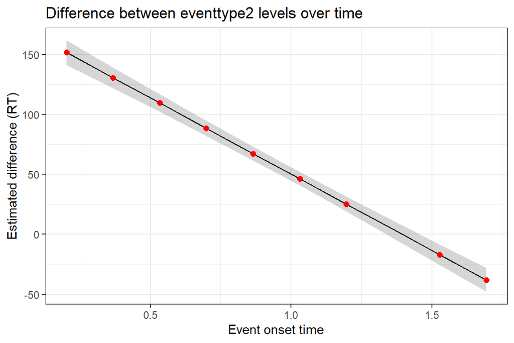

```r
contrast_results <- contrast(emm_LMRT_full, method = "pairwise", adjust = "tukey")
# summary(contrast_results)
results_df <- as.data.frame(contrast_results)
significant_times <- subset(results_df, p.value < 0.05)

ggplot(results_df, aes(x = eventonsettimes, y = estimate)) +
  geom_line() +
  geom_ribbon(aes(ymin = estimate - SE, ymax = estimate + SE), alpha = 0.2) +
  geom_point(data = significant_times, color = "red", size = 2) +
  labs(title = "Difference between eventtype2 levels over time",
       y = "Estimated difference (RT)", x = "Event onset time")
```

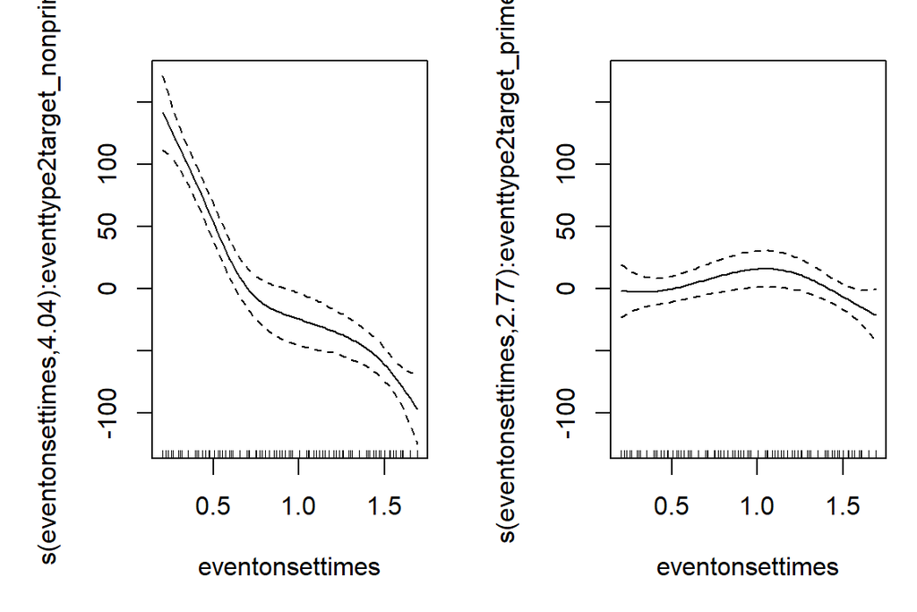

```r
# Model with smoothers by condition
model_gam_interaction <- DATA_Trials %>%
  filter(response=='hit')%>%
  mutate(eventtype2 = as.factor(eventtype2))%>%
  gam(RT ~ eventtype2 + s(eventonsettimes, by = eventtype2, bs = "cs") + participant,
                 data = .)

model_gam_null <- DATA_Trials %>%
  filter(response=='hit')%>%
  mutate(eventtype2 = as.factor(eventtype2))%>%
  gam(RT ~ eventtype2 + s(eventonsettimes, bs = "cs") +participant,
                 data = .)

plot(model_gam_interaction, pages = 1)
```

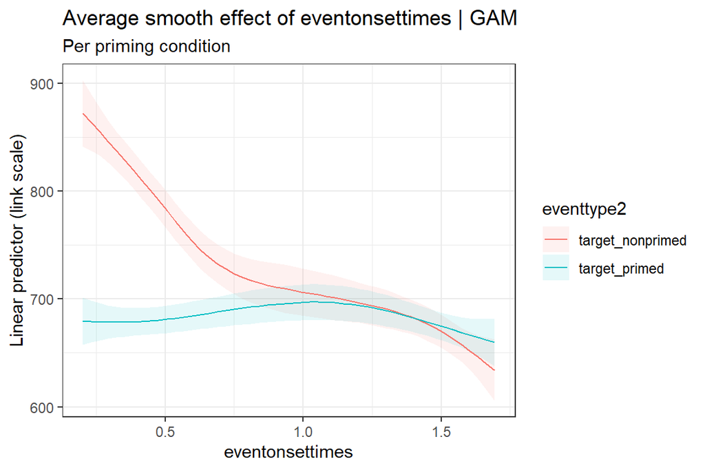

```r
# anova(model_gam_interaction)


plot_predictions(model_gam_interaction, condition = c('eventonsettimes', 'eventtype2'),
                 type = 'link') +
      labs(y = "Linear predictor (link scale)",
           title = "Average smooth effect of eventonsettimes | GAM",
           subtitle = "Per priming condition")
```

```r
# Likelihood ratio test
anova( model_gam_null, model_gam_interaction, test = "Chisq") %>%
  tidy()%>%
  # as.data.frame() %>%
  # mutate(model = c('reduced model','full model')) %>%
  # dplyr::select(model, `Resid. Df`:`Pr(>Chi)`)%>%
  kbl(escape = F, digits=3,
      caption = paste0("Likelihood ratio test via anova | comparing full and reduced model | GAM:"))%>%
        # caption = paste0("Likelihood ratio test via anova | comparing full and reduced model | GAM:<br>",
        #             paste(deparse(formula(model_gam_interaction)), collapse = " ")))%>%
  kable_styling("striped", full_width = T, bootstrap_options = c("striped", "hover", "condensed", "responsive",font_size = 8,latex_options = "hold_position"))
```

Likelihood ratio test via anova | comparing full and reduced model | GAM:

| term | df.residual | residual.deviance | df | deviance | p.value |
| --- | --- | --- | --- | --- | --- |
| RT ~ eventtype2 + s(eventonsettimes, bs = “cs”) + participant | 3700.3 | 119694896 | NA | NA | NA |
| RT ~ eventtype2 + s(eventonsettimes, by = eventtype2, bs = “cs”) + participant | 3695.6 | 115358169 | 4.656 | 4336727 | 0 |

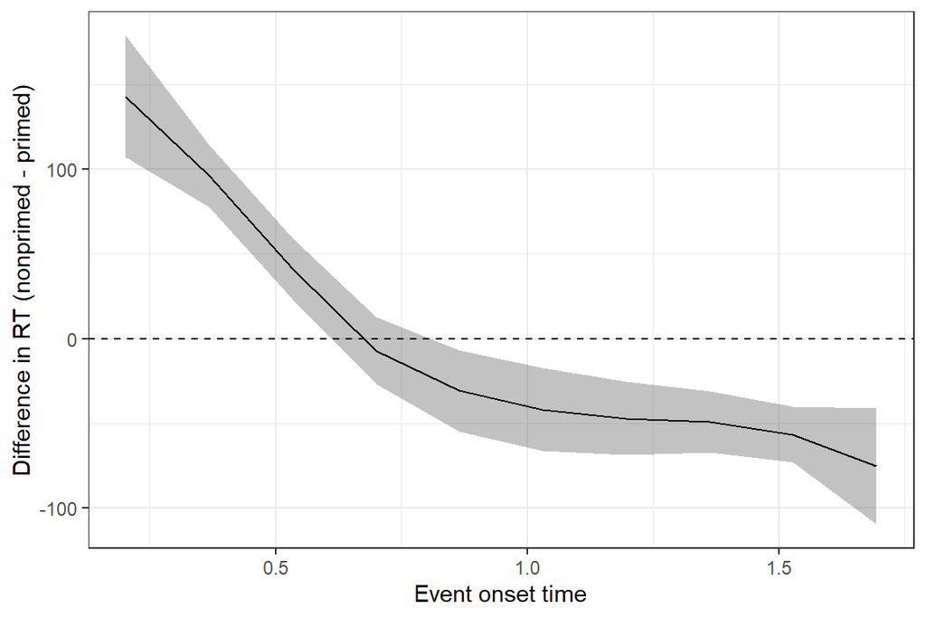

```r
# Plot difference between smooths (e.g., eventtype2 levels "A" and "B")
diff_df <- difference_smooths(model_gam_interaction,
                               smooth = "s(eventonsettimes)",
                               comparison = c("eventtype2A", "eventtype2B"),
                               n = 10)  # 200 points across the range

ggplot(diff_df, aes(x = eventonsettimes, y = .diff)) +
  geom_line() +
  geom_ribbon(aes(ymin = .lower_ci, ymax = .upper_ci), alpha = 0.3) +
  geom_hline(yintercept = 0, linetype = "dashed") +
  labs(x = "Event onset time", y = "Difference in RT (nonprimed - primed)")
```

##### follow up: directly test time windows | RTs

*Do RTs for primed and non-primed events differ (differently) across time?*

full model: RT ~ eventtype2 * eventonsettimes + (1 | participant)

Test rationale: do these models differ significantly and does the interaction term thus allow for a better explanation of the data.

Extract predicted probability of RTs for early and late window and contrast them

```r
# Full model with interaction
# Model with smoothers by condition
model_gam_interaction <- DATA_Trials %>%
  filter(response=='hit')%>%
  mutate(eventtype2 = as.factor(eventtype2))%>%
  gam(RT ~ eventtype2 + s(eventonsettimes, by = eventtype2, bs = "cs") + participant,
                 data = .)

# based on gam interactions
# Define the time windows
early_window <- c(0, 0.5) + min(DATA_Trials$eventonsettimes)
late_window <- c(-0.5, 0) + max(DATA_Trials$eventonsettimes)

# Calculate the average predicted hit probability for each time window
# and for each event type (attended vs. unattended).
# We'll use the 'at' argument to specify the time points of interest.
emm_predictions <- emmeans(
  model_gam_interaction,
  ~ eventtype2 | eventonsettimes,
  at = list(eventonsettimes = c(mean(early_window), mean(late_window)))
)

summary(emm_predictions, type = "response") %>%
  as.data.frame()%>%
  mutate(eventonsettimes=c("early","early","late","late"))%>%
  kbl(escape = F, digits=4,
      caption = paste0("Marginal Mean predicted RTs in early and late time window"))%>%
        # caption = paste0("Likelihood ratio test via anova | comparing full and reduced model | GAM:<br>",
        #             paste(deparse(formula(model_gam_interaction)), collapse = " ")))%>%
  kable_styling("striped", full_width = T, bootstrap_options = c("striped", "hover", "condensed", "responsive",font_size = 8,latex_options = "hold_position"))
```

Marginal Mean predicted RTs in early and late time window

| eventtype2 | eventonsettimes | emmean | SE | df | lower.CL | upper.CL |
| --- | --- | --- | --- | --- | --- | --- |
| target_nonprimed | early | 798.91 | 8.6310 | 3697.2 | 781.99 | 815.83 |
| target_primed | early | 679.78 | 6.3474 | 3697.2 | 667.34 | 692.22 |
| target_nonprimed | late | 677.71 | 7.9687 | 3697.2 | 662.08 | 693.33 |
| target_primed | late | 679.17 | 6.5363 | 3697.2 | 666.36 | 691.99 |

```r
# Now, set up the contrast to compare early vs. late for each condition.
# This will perform a pairwise comparison for each event type.
# do everything on the response scale, i.e. probability scale
emm_response_scale <- regrid(emm_predictions)

# Now perform the contrasts on the regridded object
contrast_tdiffs <- contrast(
  emm_response_scale,
  method = "pairwise",
  by = "eventtype2",
  adjust= "holm"
)


# View the results on the probability scale
summary(contrast_tdiffs) %>%
  as.data.frame()%>%
  mutate(contrast = c("early vs late"))%>%
  mutate(
    p.value = cell_spec(ifelse(round(p.value,4)<.001,"< .001",round(p.value,4)),
                        color = ifelse(is.nan(p.value),"blue", ifelse(p.value < .05, "green", "red")),
                        bold = ifelse(is.nan(p.value),F, ifelse(p.value < .05, T,F)),
                        align = "center")
  ) %>%
  mutate(`CohensD1` =
           summary(eff_size(contrast_tdiffs,
                            sigma = sqrt(mean(sigma(model_gam_interaction, type = "response")^2)), # RMS of sigma()
                            edf = df.residual(model_gam_interaction), method = "identity"))$effect.size
  )%>%
  mutate(`CohensD2` =
           summary(eff_size(contrast_tdiffs,
                            sigma = sqrt(mean(sigma(model_gam_interaction, type = "response")^2)), # RMS of sigma()
                            edf = sum(model_gam_interaction$edf), method = "identity"))$effect.size
  )%>%
  kbl(escape = F, digits=4,
      caption = paste0("Contrast of marginal means of RTs between early and late time window | Holm corrected"))%>%
        # caption = paste0("Likelihood ratio test via anova | comparing full and reduced model | GAM:<br>",
        #             paste(deparse(formula(model_gam_interaction)), collapse = " ")))%>%
  kable_styling("striped", full_width = T, bootstrap_options = c("striped", "hover", "condensed", "responsive",font_size = 8,latex_options = "hold_position"))
```

Contrast of marginal means of RTs between early and late time window | Holm corrected

| contrast | eventtype2 | estimate | SE | df | t.ratio | p.value | CohensD1 | CohensD2 |
| --- | --- | --- | --- | --- | --- | --- | --- | --- |
| early vs late | target_nonprimed | 121.201 | 11.7502 | 3697.2 | 10.3149 | < .001 | 0.6862 | 0.6862 |
| early vs late | target_primed | 0.608 | 9.2224 | 3697.2 | 0.0659 | 0.9474 | 0.0034 | 0.0034 |

```r
# Now perform the contrasts on the regridded object
contrast_condiffs <- contrast(
  emm_response_scale,
  method = "pairwise",
  by = "eventonsettimes",
  adjust= "holm"
)


# View the results on the probability scale
summary(contrast_condiffs) %>%
  as.data.frame()%>%
  mutate(eventonsettimes = c("early","late"))%>%
  mutate(
    p.value = cell_spec(ifelse(round(p.value,4)<.001,"< .001",round(p.value,4)),
                        color = ifelse(is.nan(p.value),"blue", ifelse(p.value < .05, "green", "red")),
                        bold = ifelse(is.nan(p.value),F, ifelse(p.value < .05, T,F)),
                        align = "center")
  ) %>%
  mutate(`CohensD1` =
           summary(eff_size(contrast_condiffs,
                            sigma = sqrt(mean(sigma(model_gam_interaction, type = "response")^2)), # RMS of sigma()
                            edf = df.residual(model_gam_interaction), method = "identity"))$effect.size
  )%>%
  mutate(`CohensD2` =
           summary(eff_size(contrast_condiffs,
                            sigma = sqrt(mean(sigma(model_gam_interaction, type = "response")^2)), # RMS of sigma()
                            edf = sum(model_gam_interaction$edf), method = "identity"))$effect.size
  )%>%
  kbl(escape = F, digits=4,
      caption = paste0("Contrast of marginal means of RTs between conditions | Holm corrected"))%>%
        # caption = paste0("Likelihood ratio test via anova | comparing full and reduced model | GAM:<br>",
        #             paste(deparse(formula(model_gam_interaction)), collapse = " ")))%>%
  kable_styling("striped", full_width = T, bootstrap_options = c("striped", "hover", "condensed", "responsive",font_size = 8,latex_options = "hold_position"))
```

Contrast of marginal means of RTs between conditions | Holm corrected

| contrast | eventonsettimes | estimate | SE | df | t.ratio | p.value | CohensD1 | CohensD2 |
| --- | --- | --- | --- | --- | --- | --- | --- | --- |
| target_nonprimed - target_primed | early | 119.127 | 10.713 | 3697.2 | 11.1202 | < .001 | 0.6744 | 0.6744 |
| target_nonprimed - target_primed | late | -1.466 | 10.306 | 3697.2 | -0.1423 | 0.8869 | -0.0083 | -0.0083 |

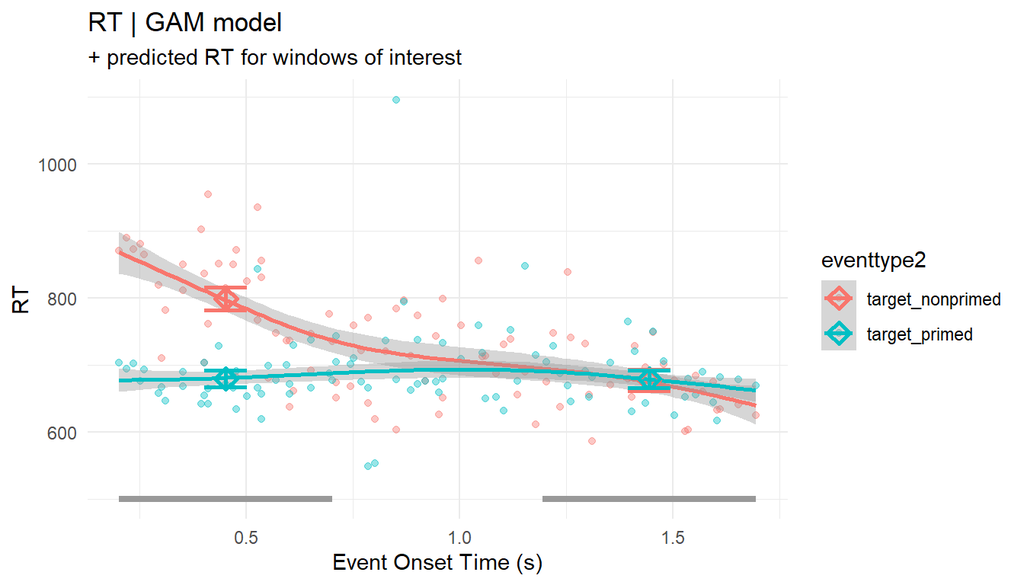

```r
emm_predictions_plot <- emmeans(
  model_gam_interaction,
  ~ eventtype2 | eventonsettimes,
  at = list(eventonsettimes = c(mean(early_window), mean(late_window)))
) %>%
  regrid()%>%
  as.data.frame()


# Base plot with original data and GAM smoothed line
DATA_Trials %>%
  filter(response=='hit')%>%
  mutate(eventtype2 = as.factor(eventtype2))%>%
  ggplot(., aes(x = eventonsettimes, y = as.numeric(RT), color = eventtype2)) +
  stat_summary(fun = mean, geom = "point", alpha = 0.4, bins=length(unique(DATA_Trials$eventonsettimes))) +
  # stat_summary(fun.data = mean_se, geom = "errorbar", width = 0.02, alpha = 0.4) + # Optional: add standard error bars
  geom_smooth(method = "gam", formula = y ~ s(x, bs = "cs"), se = TRUE, aes(group = eventtype2)) +
  labs(x = "Event Onset Time (s)", y = "RT",
       title = "RT | GAM model", subtitle = "+ predicted RT for windows of interest") +
  geom_point(data = emm_predictions_plot, aes(y = emmean, group = eventtype2), size = 3, shape = 23, stroke = 1.5) +
  geom_errorbar(data = emm_predictions_plot, aes(y = emmean,ymin = lower.CL, ymax = upper.CL), width = 0.1, size = 1) +
  # Add vertical lines for the early time window
  annotate("segment", x = early_window[1], xend = early_window[2], y = 500, yend = 500, color = "grey60", size = 1.5) +
  annotate("segment", x = late_window[1], xend = late_window[2], y = 500, yend = 500, color = "grey60", size = 1.5) +
  theme_minimal()
```

### False Alarm Rates

#### Display of smoothed False Alarm Rates across time

What are the distributions of false alarm rates across the trial?

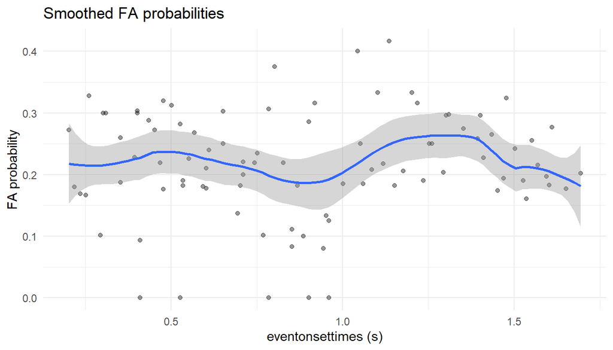

```r
DATA_FA <- DataIn1%>%
  filter(eventtype=="distractor")%>%
  mutate(FA = ifelse(response == "FA_proper", 1, 0))

ggplot(DATA_FA,aes(x = eventonsettimes, y = FA)) +
  stat_summary(fun = mean, geom = "point", alpha = 0.4) +  # mean RTs
  geom_smooth(method = "loess", se = TRUE, span = 0.3) +    # kernel smoothed average
  labs(
    title = "Smoothed FA probabilities",
    x = "eventonsettimes (s)",
    y = "FA probability"
  ) +
  theme_minimal()
```

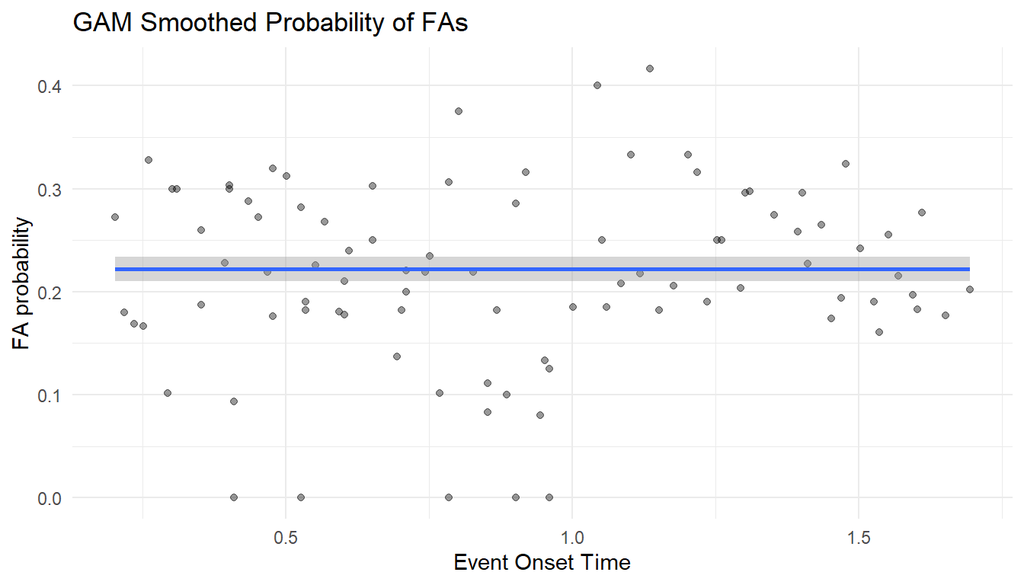

```r
ggplot(DATA_FA, aes(x = eventonsettimes, y = FA)) +
  stat_summary(fun = mean, geom = "point", alpha = 0.4) +  # mean RTs
  geom_smooth(method = "gam", formula = y ~ s(x, bs = "cs"), se = TRUE) +
  labs(x = "Event Onset Time", y = "FA probability",
       title = "GAM Smoothed Probability of FAs") +
  theme_minimal()
```

#### Statistical test for time-resolved analysis of FArate

*Does the probability of FAs differ across time?*

full model: FA ~ eventonsettimes + (1 | participant) reduced model: FA ~ 1 + (1 | participant)

Test rationale: do these models differ significantly and does the interaction term thus allow for a better explanation of the data.

```r
# Full model with factor
GLMHit_full <- DataIn1%>%
  filter(eventtype=="distractor")%>%
  mutate(response = as.factor(response)) %>%
  glmer(response ~ eventonsettimes + (1 | participant),data=., family = binomial)

# Reduced model intercept model
GLMHit_reduced <- DataIn1%>%
  filter(eventtype=="distractor")%>%
  mutate(response = as.factor(response)) %>%
  glmer(response ~ 1 + (1 | participant),data=., family = binomial)

# Likelihood ratio test
anova( GLMHit_reduced, GLMHit_full, test = "Chisq") %>%
  as.data.frame() %>%
  kable(escape = F, digits=3,
        caption = paste0("Likelihood ratio test via anova | comparing full and reduced model:<br>",
                    deparse(formula(GLMHit_full))))%>%
  kable_styling("striped", full_width = T, bootstrap_options = c("striped", "hover", "condensed", "responsive",font_size = 8,latex_options = "hold_position"))
```

Likelihood ratio test via anova | comparing full and reduced model: response ~ eventonsettimes + (1 | participant)

|  | npar | AIC | BIC | logLik | -2*log(L) | Chisq | Df | Pr(>Chisq) |
| --- | --- | --- | --- | --- | --- | --- | --- | --- |
| GLMHit_reduced | 2 | 4929.9 | 4942.9 | -2462.9 | 4925.9 | NA | NA | NA |
| GLMHit_full | 3 | 4931.9 | 4951.3 | -2462.9 | 4925.9 | 0.018 | 1 | 0.892 |

```r
# Display the summary of the full model + Wald test
GLMHit_full %>%
  tidy() %>%
  kable(escape = F, digits=3,
        caption = paste0("Likelihood ratio test via anova | comparing full and reduced model:<br>",
                    deparse(formula(GLMHit_full)))) %>%
  kable_styling("striped", full_width = T, bootstrap_options = c("striped", "hover", "condensed", "responsive",font_size = 8))
```

Likelihood ratio test via anova | comparing full and reduced model: response ~ eventonsettimes + (1 | participant)

| effect | group | term | estimate | std.error | statistic | p.value |
| --- | --- | --- | --- | --- | --- | --- |
| fixed | NA | (Intercept) | -1.343 | 0.142 | -9.435 | 0.000 |
| fixed | NA | eventonsettimes | -0.010 | 0.072 | -0.136 | 0.892 |
| ran_pars | participant | sd__(Intercept) | 0.614 | NA | NA | NA |

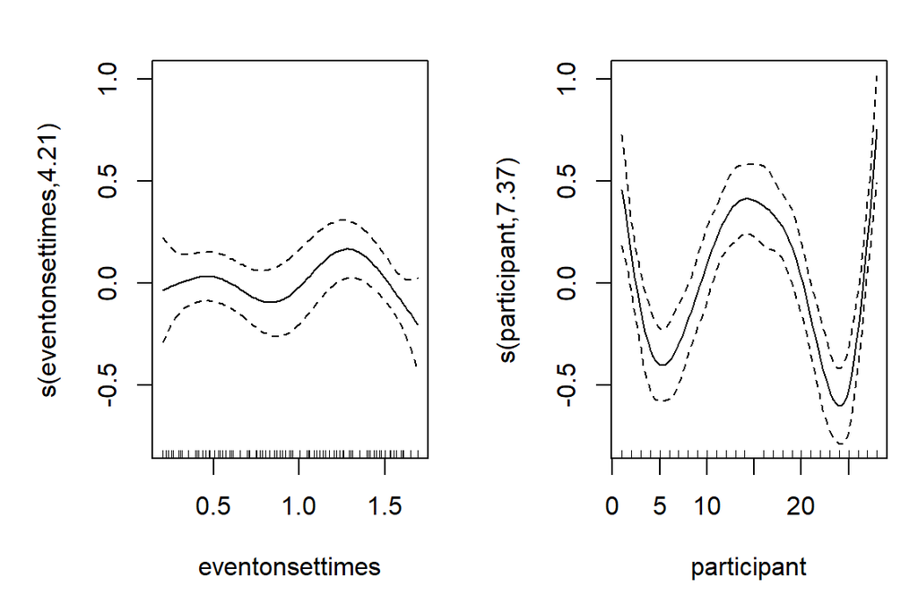

```r
# Model with smoothers by condition
model_gam_factor <- DataIn1%>%
  filter(eventtype=="distractor")%>%
  mutate(FA = ifelse(response == "FA_proper", 1, 0))%>%
  gam(FA ~ s(eventonsettimes) + s(participant, bs = "cs"),
                 data = ., family = binomial)

model_gam_null <-DataIn1%>%
  filter(eventtype=="distractor")%>%
  mutate(FA = ifelse(response == "FA_proper", 1, 0))%>%
  gam(FA ~ s(participant, bs = "cs"),
                 data = ., family = binomial)

plot(model_gam_factor, pages = 1)
```

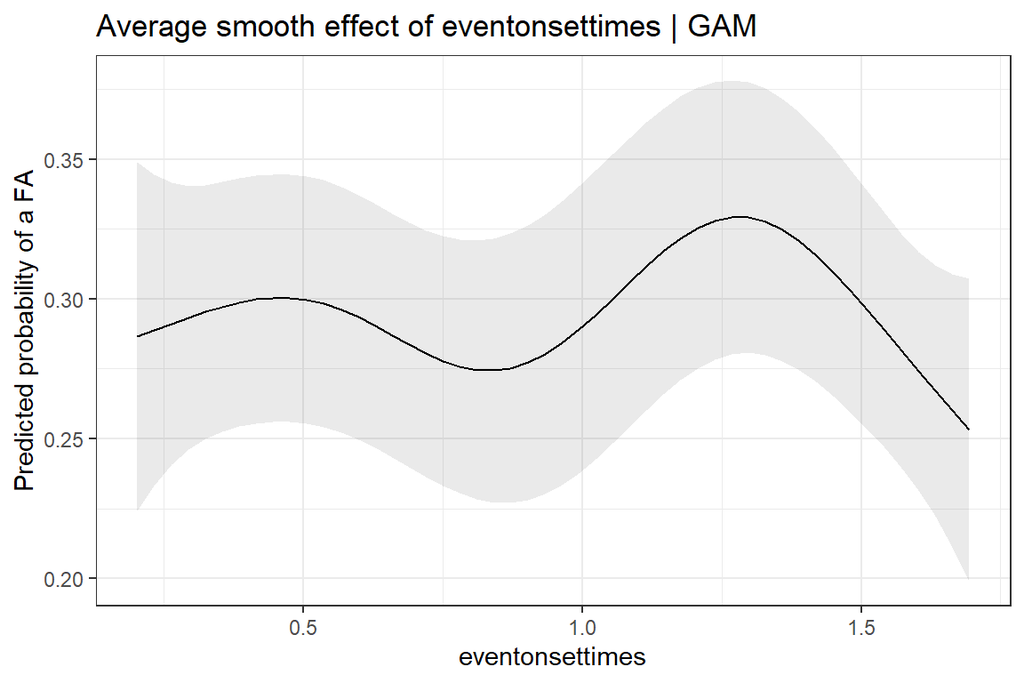

```r
# anova(model_gam_interaction)


plot_predictions(model_gam_factor, condition = 'eventonsettimes',
                 type = 'response') +
      labs(y = "Predicted probability of a FA",
           title = "Average smooth effect of eventonsettimes | GAM")
```

```r
# Likelihood ratio test
anova( model_gam_null, model_gam_factor, test = "Chisq") %>%
  tidy()%>%
  # as.data.frame() %>%
  # mutate(model = c('reduced model','full model')) %>%
  # dplyr::select(model, `Resid. Df`:`Pr(>Chi)`)%>%
  kbl(escape = F, digits=3,
      caption = paste0("Likelihood ratio test via anova | comparing full and reduced model | GAM:"))%>%
        # caption = paste0("Likelihood ratio test via anova | comparing full and reduced model | GAM:<br>",
        #             paste(deparse(formula(model_gam_interaction)), collapse = " ")))%>%
  kable_styling("striped", full_width = T, bootstrap_options = c("striped", "hover", "condensed", "responsive",font_size = 8,latex_options = "hold_position"))
```

Likelihood ratio test via anova | comparing full and reduced model | GAM:

| term | df.residual | residual.deviance | df | deviance | p.value |
| --- | --- | --- | --- | --- | --- |
| FA ~ s(participant, bs = “cs”) | 4850.7 | 5033.1 | NA | NA | NA |
| FA ~ s(eventonsettimes) + s(participant, bs = “cs”) | 4845.5 | 5022.2 | 5.172 | 10.868 | 0.06 |

Test rationale: do these models differ significantly and does the interaction term thus allow for a better explanation of the data.

```r
# Full model with interaction
# Model with smoothers by condition
model_gam_interaction <- DATA_Trials %>%
  filter(response=='hit')%>%
  mutate(eventtype2 = as.factor(eventtype2))%>%
  gam(RT ~ eventtype2 + s(eventonsettimes, by = eventtype2, bs = "cs") + participant,
                 data = .)

# based on gam interactions
# Define the time windows
early_window <- c(0, 0.5) + min(DATA_Trials$eventonsettimes)
late_window <- c(-0.5, 0) + max(DATA_Trials$eventonsettimes)

# Calculate the average predicted hit probability for each time window
# and for each event type (attended vs. unattended).
# We'll use the 'at' argument to specify the time points of interest.
emm_predictions <- emmeans(
  model_gam_interaction,
  ~ eventtype2 | eventonsettimes,
  at = list(eventonsettimes = c(mean(early_window), mean(late_window)))
)

summary(emm_predictions, type = "response") %>%
  as.data.frame()%>%
  mutate(eventonsettimes=c("early","early","late","late"))%>%
  kbl(escape = F, digits=4,
      caption = paste0("Marginal Mean predicted RTs in early and late time window"))%>%
        # caption = paste0("Likelihood ratio test via anova | comparing full and reduced model | GAM:<br>",
        #             paste(deparse(formula(model_gam_interaction)), collapse = " ")))%>%
  kable_styling("striped", full_width = T, bootstrap_options = c("striped", "hover", "condensed", "responsive",font_size = 8,latex_options = "hold_position"))
```

Marginal Mean predicted RTs in early and late time window

| eventtype2 | eventonsettimes | emmean | SE | df | lower.CL | upper.CL |
| --- | --- | --- | --- | --- | --- | --- |
| target_nonprimed | early | 798.91 | 8.6310 | 3697.2 | 781.99 | 815.83 |
| target_primed | early | 679.78 | 6.3474 | 3697.2 | 667.34 | 692.22 |
| target_nonprimed | late | 677.71 | 7.9687 | 3697.2 | 662.08 | 693.33 |
| target_primed | late | 679.17 | 6.5363 | 3697.2 | 666.36 | 691.99 |

```r
# Now, set up the contrast to compare early vs. late for each condition.
# This will perform a pairwise comparison for each event type.
# do everything on the response scale, i.e. probability scale
emm_response_scale <- regrid(emm_predictions)

# Now perform the contrasts on the regridded object
contrast_tdiffs <- contrast(
  emm_response_scale,
  method = "pairwise",
  by = "eventtype2"
)


# View the results on the probability scale
summary(contrast_tdiffs) %>%
  as.data.frame()%>%
  mutate(contrast = c("early vs late"))%>%
  mutate(
    p.value = cell_spec(ifelse(round(p.value,4)<.001,"< .001",round(p.value,4)),
                        color = ifelse(is.nan(p.value),"blue", ifelse(p.value < .05, "green", "red")),
                        bold = ifelse(is.nan(p.value),F, ifelse(p.value < .05, T,F)),
                        align = "center")
  ) %>%
  mutate(`CohensD1` =
           summary(eff_size(contrast_tdiffs,
                            sigma = sqrt(mean(sigma(model_gam_interaction, type = "response")^2)), # RMS of sigma()
                            edf = df.residual(model_gam_interaction), method = "identity"))$effect.size
  )%>%
  mutate(`CohensD2` =
           summary(eff_size(contrast_tdiffs,
                            sigma = sqrt(mean(sigma(model_gam_interaction, type = "response")^2)), # RMS of sigma()
                            edf = sum(model_gam_interaction$edf), method = "identity"))$effect.size
  )%>%
  kbl(escape = F, digits=4,
      caption = paste0("Contrast of marginal means of RTs between early and late time window"))%>%
        # caption = paste0("Likelihood ratio test via anova | comparing full and reduced model | GAM:<br>",
        #             paste(deparse(formula(model_gam_interaction)), collapse = " ")))%>%
  kable_styling("striped", full_width = T, bootstrap_options = c("striped", "hover", "condensed", "responsive",font_size = 8,latex_options = "hold_position"))
```

Contrast of marginal means of RTs between early and late time window

| contrast | eventtype2 | estimate | SE | df | t.ratio | p.value | CohensD1 | CohensD2 |
| --- | --- | --- | --- | --- | --- | --- | --- | --- |
| early vs late | target_nonprimed | 121.201 | 11.7502 | 3697.2 | 10.3149 | < .001 | 0.6862 | 0.6862 |
| early vs late | target_primed | 0.608 | 9.2224 | 3697.2 | 0.0659 | 0.9474 | 0.0034 | 0.0034 |

```r
# Now perform the contrasts on the regridded object
contrast_condiffs <- contrast(
  emm_response_scale,
  method = "pairwise",
  by = "eventonsettimes"
)


# View the results on the probability scale
summary(contrast_condiffs) %>%
  as.data.frame()%>%
  mutate(eventonsettimes = c("early","late"))%>%
  mutate(
    p.value = cell_spec(ifelse(round(p.value,4)<.001,"< .001",round(p.value,4)),
                        color = ifelse(is.nan(p.value),"blue", ifelse(p.value < .05, "green", "red")),
                        bold = ifelse(is.nan(p.value),F, ifelse(p.value < .05, T,F)),
                        align = "center")
  ) %>%
  mutate(`CohensD1` =
           summary(eff_size(contrast_condiffs,
                            sigma = sqrt(mean(sigma(model_gam_interaction, type = "response")^2)), # RMS of sigma()
                            edf = df.residual(model_gam_interaction), method = "identity"))$effect.size
  )%>%
  mutate(`CohensD2` =
           summary(eff_size(contrast_condiffs,
                            sigma = sqrt(mean(sigma(model_gam_interaction, type = "response")^2)), # RMS of sigma()
                            edf = sum(model_gam_interaction$edf), method = "identity"))$effect.size
  )%>%
  kbl(escape = F, digits=4,
      caption = paste0("Contrast of marginal means of RTs between conditions"))%>%
        # caption = paste0("Likelihood ratio test via anova | comparing full and reduced model | GAM:<br>",
        #             paste(deparse(formula(model_gam_interaction)), collapse = " ")))%>%
  kable_styling("striped", full_width = T, bootstrap_options = c("striped", "hover", "condensed", "responsive",font_size = 8,latex_options = "hold_position"))
```

Contrast of marginal means of RTs between conditions

| contrast | eventonsettimes | estimate | SE | df | t.ratio | p.value | CohensD1 | CohensD2 |
| --- | --- | --- | --- | --- | --- | --- | --- | --- |
| target_nonprimed - target_primed | early | 119.127 | 10.713 | 3697.2 | 11.1202 | < .001 | 0.6744 | 0.6744 |
| target_nonprimed - target_primed | late | -1.466 | 10.306 | 3697.2 | -0.1423 | 0.8869 | -0.0083 | -0.0083 |

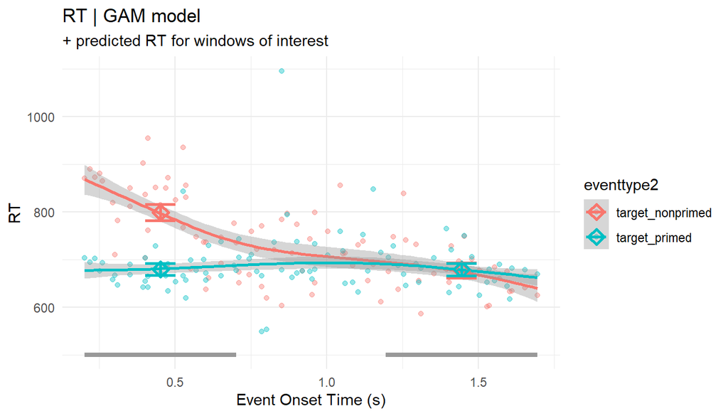

```r
emm_predictions_plot <- emmeans(
  model_gam_interaction,
  ~ eventtype2 | eventonsettimes,
  at = list(eventonsettimes = c(mean(early_window), mean(late_window)))
) %>%
  regrid()%>%
  as.data.frame()


# Base plot with original data and GAM smoothed line
DATA_Trials %>%
  filter(response=='hit')%>%
  mutate(eventtype2 = as.factor(eventtype2))%>%
  ggplot(., aes(x = eventonsettimes, y = as.numeric(RT), color = eventtype2)) +
  stat_summary(fun = mean, geom = "point", alpha = 0.4, bins=length(unique(DATA_Trials$eventonsettimes))) +
  # stat_summary(fun.data = mean_se, geom = "errorbar", width = 0.02, alpha = 0.4) + # Optional: add standard error bars
  geom_smooth(method = "gam", formula = y ~ s(x, bs = "cs"), se = TRUE, aes(group = eventtype2)) +
  labs(x = "Event Onset Time (s)", y = "RT",
       title = "RT | GAM model", subtitle = "+ predicted RT for windows of interest") +
  geom_point(data = emm_predictions_plot, aes(y = emmean, group = eventtype2), size = 3, shape = 23, stroke = 1.5) +
  geom_errorbar(data = emm_predictions_plot, aes(y = emmean,ymin = lower.CL, ymax = upper.CL), width = 0.1, size = 1) +
  # Add vertical lines for the early time window
  annotate("segment", x = early_window[1], xend = early_window[2], y = 500, yend = 500, color = "grey60", size = 1.5) +
  annotate("segment", x = late_window[1], xend = late_window[2], y = 500, yend = 500, color = "grey60", size = 1.5) +
  theme_minimal()
```

### Control Analysis: Are there differences in the distributions of event times for both cueing conditons?

Idea: can we really compare primed and non-primed events? Are their distributions of presentation times comparable?

Rationale: Can the eventtype be predicted by the presentation time? If presentation time was comparable, it shouldn’t be a predictor.

eventtype2 ~ eventonsettimes + (1 | participant)

```r
GLMEventType_full <- DATA_Trials %>%
  mutate(eventtype2 = as.factor(eventtype2)) %>%
  glmer(eventtype2 ~ eventonsettimes + (1 | participant),data=., family = binomial)
```

```
## boundary (singular) fit: see help('isSingular')
```

```r
# Display the summary of the full model + Wald test
# summary(GLMEventType_full)

# Display the summary of the full model + Wald test
GLMEventType_full %>%
  tidy() %>%
  kable(escape = F, digits=3,
        caption = paste0("Likelihood ratio test via anova | display of full model:<br>",
                    deparse(formula(GLMEventType_full)))) %>%
  kable_styling("striped", full_width = T, bootstrap_options = c("striped", "hover", "condensed", "responsive",font_size = 8))
```

Likelihood ratio test via anova | display of full model: eventtype2 ~ eventonsettimes + (1 | participant)

| effect | group | term | estimate | std.error | statistic | p.value |
| --- | --- | --- | --- | --- | --- | --- |
| fixed | NA | (Intercept) | -0.025 | 0.062 | -0.404 | 0.686 |
| fixed | NA | eventonsettimes | 0.021 | 0.057 | 0.366 | 0.714 |
| ran_pars | participant | sd__(Intercept) | 0.000 | NA | NA | NA |

### Control Analysis: Is the sequential modulation simply capturing a sequential strategy in shifting attention by the to be learned cue?

Idea: Can the sequential modulation be solely attributed to the functional classification primed vs non-primed? Or could an alternative account state that the sequential modulation is capturing a sequential strategy in shifting attention by the to be learned cue? Does it even make a difference? If it is learning related, maybe the effect is time-on-task dependent and initially higher than later on.

Rationale: Do a time-on-task resolved analysis

eventtype2 ~ eventonsettimes + (1 | participant)

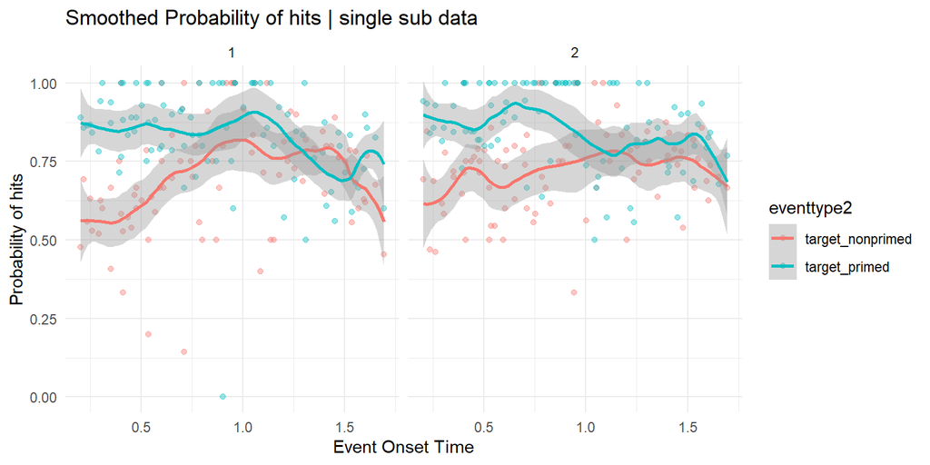

```r
data_bin <- DATA_Trials %>%
  mutate(hit = ifelse(response == "hit", 1, 0))%>%
  group_by(participant)%>%
  # mutate(time_bin = cut(trialnumber,
  #                       breaks = seq(0, max(trialnumber), by = 2),
  #                       labels = FALSE)) %>%
  mutate(time_bin = as.factor(ntile(trialnumber, 2))) %>%
  ungroup()



ggplot(data_bin, aes(x = eventonsettimes, y = hit, color = eventtype2)) +
  stat_summary(fun = mean, geom = "point", alpha = 0.4) +  # mean RTs
  geom_smooth(method = "loess", span = 0.3, se = TRUE) +
  facet_grid(.~time_bin)+
  labs(x = "Event Onset Time", y = "Probability of hits",
       title = "Smoothed Probability of hits | single sub data") +
  theme_minimal()
```

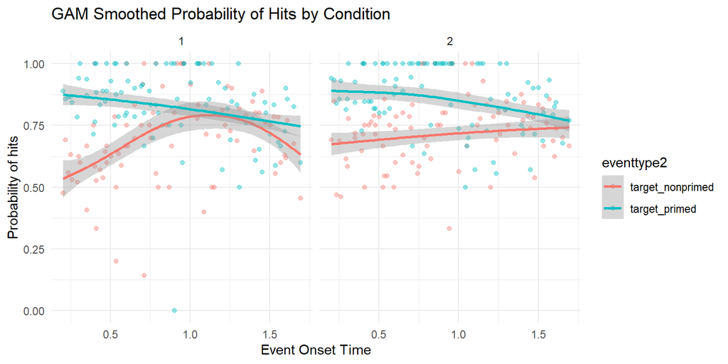

```r
# ggplot(data_avg, aes(x = eventonsettimes, y = hit_rate, color = eventtype2)) +
#   # geom_line(alpha = 0.4) +
#   stat_summary(fun = mean, geom = "point", alpha = 0.4) +  # mean RTs
#   geom_smooth(method = "loess", se = TRUE, span = 0.3) +
#   labs(x = "Event Onset Time", y = "Hit Rate",
#        title = "Smoothed Hit Rates Over Time by Condition | averaged across subjects hit rates") +
#   theme_minimal()


ggplot(data_bin, aes(x = eventonsettimes, y = hit, color = eventtype2)) +
  stat_summary(fun = mean, geom = "point", alpha = 0.4) +  # mean RTs
  geom_smooth(method = "gam", formula = y ~ s(x, bs = "cs"), se = TRUE) +
  facet_grid(.~time_bin)+
  labs(x = "Event Onset Time", y = "Probability of hits",
       title = "GAM Smoothed Probability of Hits by Condition") +
  theme_minimal()
```

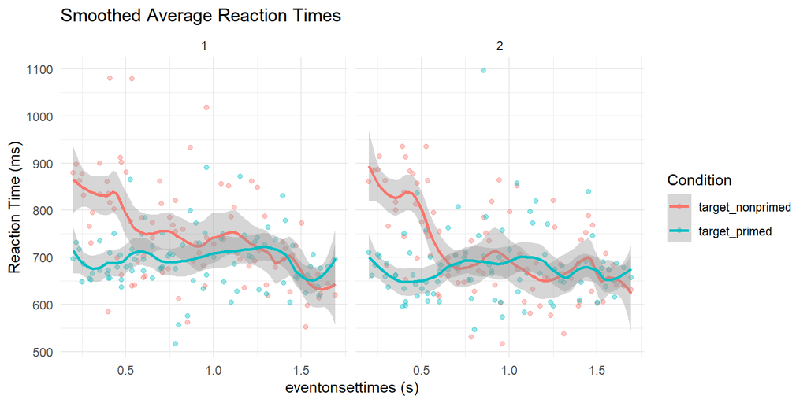

```r
data_bin %>%
  filter(response=='hit')%>%
  ggplot(aes(x = eventonsettimes, y = RT, color = eventtype2)) +
  stat_summary(fun = mean, geom = "point", alpha = 0.4) +  # mean RTs
  geom_smooth(method = "loess", se = TRUE, span = 0.3) +    # kernel smoothed average
  facet_grid(.~time_bin)+
  labs(
    title = "Smoothed Average Reaction Times",
    x = "eventonsettimes (s)",
    y = "Reaction Time (ms)",
    color = "Condition"
  ) +
  theme_minimal()
```

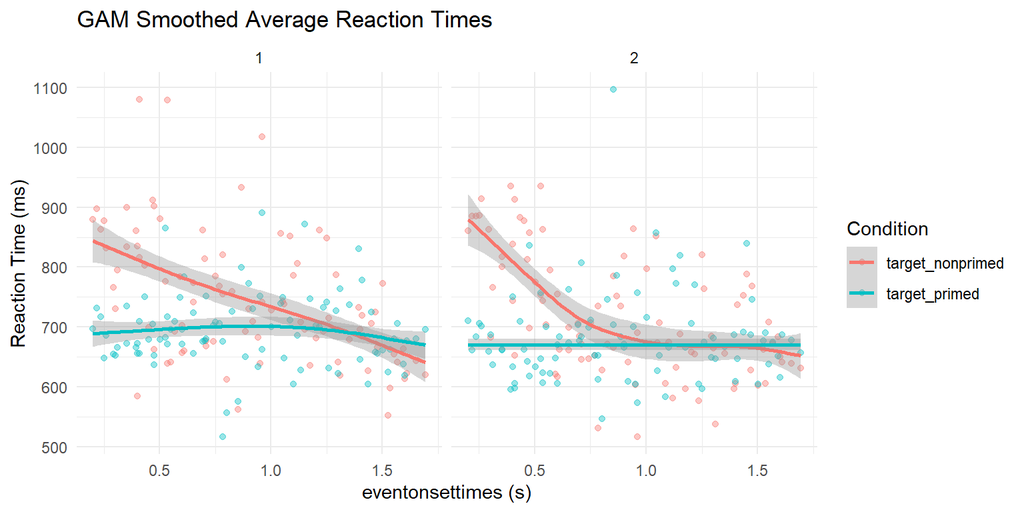

```r
data_bin %>%
  filter(response=='hit')%>%
  ggplot(aes(x = eventonsettimes, y = RT, color = eventtype2)) +
  stat_summary(fun = mean, geom = "point", alpha = 0.4) +  # mean RTs
  geom_smooth(method = "gam", formula = y ~ s(x, bs = "cs"), se = TRUE) +    # kernel smoothed average
  facet_grid(.~time_bin)+
  labs(
    title = "GAM Smoothed Average Reaction Times",
    x = "eventonsettimes (s)",
    y = "Reaction Time (ms)",
    color = "Condition"
  ) +
  theme_minimal()
```